# The Impact of COVID-19 Lockdown on Robbery Rates: An Exploratory Data Analysis (EDA) of Criminal Activity in Washington D.C.

Muhannad Alwhebie, Liang Gao, Nammin Woo

2023-03-07

# The Effect of COVID-19 Lockdown on Robbery Incidents in Washington D.C.

## Introduction

The COVID-19 pandemic has impacted various aspects of daily life, including crime rates. This EDA project examines the impact of the COVID-19 lockdown on robbery rates in Washington D.C using a dataset of roughly 8000 observations. The study analyzes the pre-pandemic, lockdown, and post-pandemic periods (2019-2022) to determine significant changes in robbery frequency. Robbery is defined by the Code of the District of Columbia as taking anything of value from the person or immediate actual possession of another by force or violence, putting in fear, or by sudden or stealthy seizure or snatching. The project explores differences in robbery patterns during the pandemic compared to pre/post-pandemic times. It also investigates changes in the relationship between the day of the week and the frequency of robberies before and after the pandemic period. Additionally, the project examines changes in the relationship between the day of the month and the frequency of robberies before and after the pandemic period. Finally, the study identifies significant changes in the frequency of robberies among districts before and after the pandemic.

The study by Boman and Gallupe (2020), suggests that the COVID-19 pandemic and the associated mandatory stay-at-home orders have had a differential impact on crime rates in the US. While overall crime rates, as measured by calls for service to law enforcement, have decreased compared to the pre-pandemic year of 2019, this drop appears to be driven by decreases in minor offenses that are typically committed in peer groups. In contrast, serious crimes that are generally not committed with co-offenders, such as homicide and intimate partner violence, have either remained constant or increased. The study raises the possibility that mandatory lockdown orders may have displaced minor offenders into situations where there is a greater opportunity for serious crimes, particularly intimate partner violence and homicide.

In order to understand the impact of COVID-19 lockdown on robbery rates in Washington D.C, it is important to first examine the overall crime rates in the area prior to the pandemic. According to the Metropolitan Police Department’s crime statistics, the overall crime rate in Washington D.C. has been decreasing in recent years. In 2019, there were 31,700 reported incidents of crime, a decrease from 37,265 in 2016. However, within this overall trend, there have been fluctuations in specific types of crimes, including robbery. Moreover, Robbery has been a persistent problem in Washington D.C., particularly in certain areas of the city. In 2019, there were 2,700 reported incidents of robbery, down from 2,977 in 2015. As such, it is important to examine how the COVID-19 pandemic and associated lockdown measures have impacted robbery rates in the city. This analysis will provide insight into how the pandemic has affected crime patterns in a major urban area and may inform future policy decisions related to crime prevention and public safety.

## Methodology

### 1. Data

The dataset contains detailed information on robbery incidents that occurred between 2019 and 2022, and we extracted this information into our dataset titled “Robbery_DC_clean.csv”.

In this section, we will provide a commentary on the data, highlighting its strengths and limitations. This information is critical in providing context for the analysis and understanding the potential impact of any data-related issues on the conclusions drawn from our analysis.

Furthermore, we will discuss the data cleaning and preprocessing steps taken to ensure that the data is suitable for analysis. These steps include removing duplicate records, addressing missing values, and identifying and handling outliers.

We will also provide an overview of the variables included in the dataset, such as the date and time of the robbery incident, the location of the incident, the method used, and other relevant details. This information is essential in developing a comprehensive understanding of the robbery incidents and their potential relationship to the COVID-19 lockdown.

Overall, this section provides a solid foundation for the analysis that follows, and we have taken great care to ensure that the data is reliable, relevant, and suitable for our analysis.

### 2. Data Wrangling and Preprocessing

```r
#Import
Robbery = data.frame(read.csv("Robbery_DC_clean.csv"))

#Import
#str(Robbery)
```

This section typically involves importing, cleaning, and pre-processing raw data to prepare it for analysis. The data cleaning process include removing duplicate records, addressing missing values, identifying and handling outliers, and transforming variables as needed. By performing these steps, we can ensure that the data is suitable for analysis and that our conclusions are based on accurate and reliable information. In this section, we will provide an overview of the data wrangling and pre-processing steps taken for the “Robbery_DC_clean.csv” dataset used in our analysis.

```r
#create Clearance_rate(Unit: Minute)= END_DATE - START_DATE

#1. 'Date' format

Robbery$START_DATE_2 <- as.POSIXct(Robbery$START_DATE,format = "%Y/%m/%d %H:%M:%S")
Robbery$END_DATE_2 <- as.POSIXct(Robbery$END_DATE,format = "%Y/%m/%d %H:%M:%S")
```

```r
Robbery$Clearance_rate <- as.numeric(difftime(strptime(Robbery$END_DATE_2,"%Y-%m-%d%H:%M:%S"),strptime(Robbery$START_DATE_2,"%Y-%m-%d %H:%M:%S")))/60

Robbery$Clearance_rate <- format(round(Robbery$Clearance_rate, 0), nsmall = 0)
Robbery$Clearance_rate<- as.integer(Robbery$Clearance_rate)
```

```r
#head(select(Robbery,START_DATE, START_DATE_2, END_DATE_2,Clearance_rate),5)
#strptime(paste(Robbery$START_DATE, Robbery$END_DATE), "%Y-%m-%d")  #%H:%M

#column remove
Robbery <- select(Robbery,-Robbery_Time, -START_DATE, -END_DATE)
#as.numeric(difftime(strptime(END_DATE_2,"%Y-%m-%d%H:%M:%S"),strptime(START_DATE_2,"%Y-%m-%d %H:%M:%S")))

#rename
Robbery <-rename(Robbery, START_DATE = START_DATE_2)
Robbery <-rename(Robbery, END_DATE = END_DATE_2)
```

```r
# change datatypes of Char.var for EDA (as Factor)
cols <- c('Period_cat','Period_cat_2','Month_2','Month_3','Season','Date_cat','Day_cat_2','SHIFT','METHOD')


Robbery %<>%
       mutate_each_(funs(factor(.)),cols)

#Category var. label order fix
Robbery$Period_cat <- factor(Robbery$Period_cat, levels=c("Pre", "Lock", "Post"))

Robbery$Season <- factor(Robbery$Season, levels=c("SPRING", "SUMMER", "AUTUMN", "WINTER"))

#Robbery$SHIFT<- as.factor(Robbery$SHIFT)
```

*The variables in the dataset are:*

```r
str(Robbery)
```

```
## 'data.frame':    8343 obs. of  24 variables:
##  $ OBJECTID      : int  293676435 293907395 293676443 293904185 293912806 293909584 293677243 293677250 293677649 293911786 ...
##  $ Seq           : int  1 2 3 4 5 6 7 8 9 10 ...
##  $ OFFENSE       : chr  "ROBBERY" "ROBBERY" "ROBBERY" "ROBBERY" ...
##  $ REPORT_DAT    : chr  "2019/01/01 07:53:38+00" "2019/01/01 08:50:09+00" "2019/01/01 11:54:54+00" "2019/01/01 20:21:41+00" ...
##  $ REPORT_DAT_2  : chr  "1/1/2019" "1/1/2019" "1/1/2019" "1/1/2019" ...
##  $ Period_cat    : Factor w/ 3 levels "Pre","Lock","Post": 1 1 1 1 1 1 1 1 1 1 ...
##  $ Period_cat_2  : Factor w/ 4 levels "Lock","Post",..: 3 3 3 3 3 3 3 3 3 3 ...
##  $ Year          : int  2019 2019 2019 2019 2019 2019 2019 2019 2019 2019 ...
##  $ Month         : int  1 1 1 1 1 1 1 1 1 1 ...
##  $ Month_2       : Factor w/ 48 levels "19_1","19_10",..: 1 1 1 1 1 1 1 1 1 1 ...
##  $ Month_3       : Factor w/ 48 levels "2019/01","2019/02",..: 1 1 1 1 1 1 1 1 1 1 ...
##  $ Season        : Factor w/ 4 levels "SPRING","SUMMER",..: 4 4 4 4 4 4 4 4 4 4 ...
##  $ Date          : int  1 1 1 1 1 2 2 2 3 3 ...
##  $ Date_cat      : Factor w/ 3 levels "Begin","End",..: 1 1 1 1 1 1 1 1 1 1 ...
##  $ Time_hour     : int  7 8 11 20 23 0 19 20 1 2 ...
##  $ SHIFT         : Factor w/ 3 levels "DAY","EVENING",..: 3 3 3 2 2 2 1 2 2 2 ...
##  $ Day_cat       : int  3 3 3 3 3 4 4 4 5 5 ...
##  $ Day_cat_2     : Factor w/ 2 levels "Weekday","Weekend": 1 1 1 1 1 1 1 1 1 1 ...
##  $ METHOD        : Factor w/ 3 levels "GUN","KNIFE",..: 1 3 3 1 2 3 3 1 3 3 ...
##  $ DISTRICT      : int  5 5 5 7 6 1 6 1 7 7 ...
##  $ PSA           : int  503 507 502 708 604 108 606 104 703 706 ...
##  $ START_DATE    : POSIXct, format: "2019-01-01 07:14:47" "2019-01-01 08:00:07" ...
##  $ END_DATE      : POSIXct, format: NA "2019-01-01 08:06:21" ...
##  $ Clearance_rate: int  NA 6 NA 116 NA NA 0 6 2 19 ...
```

```r
#colnames(Robbery)
#ncol(Robbery)
#nrow(Robbery)
```

*The first 4 rows of the dataframe are:*

```r
xkabledply(Robbery[1:4,], title = "First Four Rows of Dataframe: `Robbery`")
```

First Four Rows of Dataframe: `Robbery`

| OBJECTID | Seq | OFFENSE | REPORT_DAT | REPORT_DAT_2 | Period_cat | Period_cat_2 | Year | Month | Month_2 | Month_3 | Season | Date | Date_cat | Time_hour | SHIFT | Day_cat | Day_cat_2 | METHOD | DISTRICT | PSA | START_DATE | END_DATE | Clearance_rate |
| --- | --- | --- | --- | --- | --- | --- | --- | --- | --- | --- | --- | --- | --- | --- | --- | --- | --- | --- | --- | --- | --- | --- | --- |
| 293676435 | 1 | ROBBERY | 2019/01/01 07:53:38+00 | 1/1/2019 | Pre | Pre_1 | 2019 | 1 | 19_1 | 2019/01 | WINTER | 1 | Begin | 7 | MIDNIGHT | 3 | Weekday | GUN | 5 | 503 | 2019-01-01 07:14:47 | NA | NA |
| 293907395 | 2 | ROBBERY | 2019/01/01 08:50:09+00 | 1/1/2019 | Pre | Pre_1 | 2019 | 1 | 19_1 | 2019/01 | WINTER | 1 | Begin | 8 | MIDNIGHT | 3 | Weekday | OTHERS | 5 | 507 | 2019-01-01 08:00:07 | 2019-01-01 08:06:21 | 6 |
| 293676443 | 3 | ROBBERY | 2019/01/01 11:54:54+00 | 1/1/2019 | Pre | Pre_1 | 2019 | 1 | 19_1 | 2019/01 | WINTER | 1 | Begin | 11 | MIDNIGHT | 3 | Weekday | OTHERS | 5 | 502 | 2019-01-01 10:38:29 | NA | NA |
| 293904185 | 4 | ROBBERY | 2019/01/01 20:21:41+00 | 1/1/2019 | Pre | Pre_1 | 2019 | 1 | 19_1 | 2019/01 | WINTER | 1 | Begin | 20 | EVENING | 3 | Weekday | GUN | 7 | 708 | 2019-01-01 18:16:00 | 2019-01-01 20:11:43 | 116 |

*The last 4 rows of the dataframe are*

```r
xkabledply(Robbery[(nrow(Robbery)-3):nrow(Robbery),], title = "Last Four Rows of Dataframe: `Robbery`")
```

Last Four Rows of Dataframe: `Robbery`

|  | OBJECTID | Seq | OFFENSE | REPORT_DAT | REPORT_DAT_2 | Period_cat | Period_cat_2 | Year | Month | Month_2 | Month_3 | Season | Date | Date_cat | Time_hour | SHIFT | Day_cat | Day_cat_2 | METHOD | DISTRICT | PSA | START_DATE | END_DATE | Clearance_rate |
| --- | --- | --- | --- | --- | --- | --- | --- | --- | --- | --- | --- | --- | --- | --- | --- | --- | --- | --- | --- | --- | --- | --- | --- | --- |
| 8340 | 293425007 | 8340 | ROBBERY | 2022/12/31 11:32:25+00 | 12/31/2022 | Post | Post | 2022 | 12 | 22_12 | 2022/12 | WINTER | 31 | End | 11 | MIDNIGHT | 7 | Weekend | GUN | 3 | 307 | 2022-12-31 09:45:00 | 2022-12-31 11:32:00 | 107 |
| 8341 | 293891566 | 8341 | ROBBERY | 2022/12/31 17:55:35+00 | 12/31/2022 | Post | Post | 2022 | 12 | 22_12 | 2022/12 | WINTER | 31 | End | 17 | DAY | 7 | Weekend | GUN | 6 | 607 | 2022-12-31 16:56:00 | 2022-12-31 17:05:00 | 9 |
| 8342 | 293425116 | 8342 | ROBBERY | 2022/12/31 18:41:36+00 | 12/31/2022 | Post | Post | 2022 | 12 | 22_12 | 2022/12 | WINTER | 31 | End | 18 | DAY | 7 | Weekend | GUN | 6 | 602 | 2022-12-31 17:00:00 | 2022-12-31 18:00:00 | 60 |
| 8343 | 293891569 | 8343 | ROBBERY | 2022/12/31 21:26:35+00 | 12/31/2022 | Post | Post | 2022 | 12 | 22_12 | 2022/12 | WINTER | 31 | End | 21 | EVENING | 7 | Weekend | GUN | 7 | 701 | 2022-12-31 19:08:00 | NA | NA |

## Analysis

### 1. Summary statistics of robbery incidents in D.C. before, during the COVID-19 lockdown and post

In this section, we provide a detailed overview of the summary statistics of some quantitative datas in our data set. This information includes measures such as the mean, median, standard deviation, minimum, and maximum values.

We will also examine other measures, such as the interquartile range (IQR) and coefficient of variation, to provide a more comprehensive understanding of the data’s variability and dispersion.

By analyzing the summary statistics, we can identify any significant trends or patterns in the data, such as the overall frequency of robbery incidents, the distribution of robbery incidents across different days of the week or months, and the most common methods used in robbery incidents.

We will also provide a commentary on the summary statistics, highlighting any notable findings or trends that may impact the analysis of the data. This analysis will help to identify potential issues or areas of interest that require further investigation in subsequent sections of the report.

Overall, the summary statistics provide a critical foundation for the analysis of the robbery data, enabling us to develop a more accurate and detailed understanding of the impact of the COVID-19 lockdown on robbery rates in Washington D.C.

```r
#Summary
#columns to analyse
cols <- c('Period_cat','Period_cat_2','Year', 'Month',
          'Season','Date_cat','Date',
          'SHIFT','Time_hour','Clearance_rate','Day_cat','Day_cat_2',
          'METHOD','DISTRICT','PSA')

knitr::kable(summary(select(Robbery,cols)), format = "markdown", caption="Overall summary statistics of Robbery between 2019 to 2022 in D.C")
```

Overall summary statistics of Robbery between 2019 to 2022 in D.C

|  | Period_cat | Period_cat_2 | Year | Month | Season | Date_cat | Date | SHIFT | Time_hour | Clearance_rate | Day_cat | Day_cat_2 | METHOD | DISTRICT | PSA |
| --- | --- | --- | --- | --- | --- | --- | --- | --- | --- | --- | --- | --- | --- | --- | --- |
|  | Pre :2535 | Lock :2648 | Min. :2019 | Min. : 1.00 | SPRING:1585 | Begin :2344 | Min. : 1 | DAY :1657 | Min. : 0.00 | Min. : 0 | Min. :1.00 | Weekday:5716 | GUN :4031 | Min. :1.00 | Min. :101 |
|  | Lock:2729 | Post :3121 | 1st Qu.:2019 | 1st Qu.: 4.00 | SUMMER:2236 | End :3195 | 1st Qu.: 9 | EVENING :3305 | 1st Qu.: 3.00 | 1st Qu.: 5 | 1st Qu.:2.00 | Weekend:2627 | KNIFE : 508 | 1st Qu.:3.00 | 1st Qu.:302 |
|  | Post:3079 | Pre_1:2232 | Median :2020 | Median : 7.00 | AUTUMN:2449 | Middle:2804 | Median :16 | MIDNIGHT:3381 | Median : 7.00 | Median : 32 | Median :4.00 | NA | OTHERS:3804 | Median :4.00 | Median :408 |
|  | NA | Pre_2: 342 | Mean :2020 | Mean : 6.81 | WINTER:2073 | NA | Mean :16 | NA | Mean : 9.73 | Mean : 215 | Mean :3.98 | NA | NA | Mean :4.22 | Mean :427 |
|  | NA | NA | 3rd Qu.:2021 | 3rd Qu.:10.00 | NA | NA | 3rd Qu.:23 | NA | 3rd Qu.:17.00 | 3rd Qu.: 92 | 3rd Qu.:6.00 | NA | NA | 3rd Qu.:6.00 | 3rd Qu.:603 |
|  | NA | NA | Max. :2022 | Max. :12.00 | NA | NA | Max. :31 | NA | Max. :23.00 | Max. :291213 | Max. :7.00 | NA | NA | Max. :7.00 | Max. :708 |
|  | NA | NA | NA | NA | NA | NA | NA | NA | NA | NA’s :1701 | NA | NA | NA | NA’s :21 | NA’s :22 |

```r
#Freq
#Robbery %>%
#  count(Clearance_rate)

#Where
#Robbery |>
#  filter(Clearance_rate > 1440)  # more that one-day
```

Key statistics of individual Quantitative variable are:

- `Month`: Mean(6.812), Standard deviation(3.472), Variance(12.052)

```r
mean(Robbery$Month,na.rm = TRUE)
```

```
## [1] 6.81
```

```r
sd(Robbery$Month, na.rm = TRUE)
```

```
## [1] 3.47
```

```r
var(Robbery$Month, na.rm = TRUE)
```

```
## [1] 12.1
```

- `Date`: Mean(15.974), Standard deviation(8.73), Variance(76.211)

```r
mean(Robbery$Date,na.rm = TRUE)
```

```
## [1] 16
```

```r
sd(Robbery$Date, na.rm = TRUE)
```

```
## [1] 8.73
```

```r
var(Robbery$Date, na.rm = TRUE)
```

```
## [1] 76.2
```

- **`Day_cat`** (Sun= 1, Mon:2, Tue:3, Wed:4, Thr:5, Fri: 6, Sat: 7): Mean(3.984), Standard deviation(2.05), Variance(4.202)

```r
mean(Robbery$Day_cat,na.rm = TRUE)
```

```
## [1] 3.98
```

```r
sd(Robbery$Day_cat, na.rm = TRUE)
```

```
## [1] 2.05
```

```r
var(Robbery$Day_cat, na.rm = TRUE)
```

```
## [1] 4.2
```

- **`Time_hour`**
1. Mean(9.73), Standard deviation(7.386), Variance(54.551)
2. AM7~12: 1568, PM 12~18: 1114, 18~23:1937, **0~7: 3724**(45)%,

```r
mean(Robbery$Time_hour,na.rm = TRUE)
```

```
## [1] 9.73
```

```r
sd(Robbery$Time_hour, na.rm = TRUE)
```

```
## [1] 7.39
```

```r
var(Robbery$Time_hour, na.rm = TRUE)
```

```
## [1] 54.6
```

```r
# 7~12: 1568, 12~18: 1114, 18~24:1937, 0~7: 3724,
#Robbery |>
#  filter(Time_hour>=0,Time_hour<7)

#Robbery |>
# filter(Time_hour>=18,Time_hour<24)
```

- **`Clearance_rate`** (Minute, `END_DATE` - `START_DATE`, )
1. Mean(214.55), Standard deviation(4095.62), Variance(16774106.636)
2. Freq: more than 1 hour is **2599**(31%)

```r
mean(Robbery$Clearance_rate,na.rm = TRUE)
```

```
## [1] 215
```

```r
sd(Robbery$Clearance_rate, na.rm = TRUE)
```

```
## [1] 4096
```

```r
var(Robbery$Clearance_rate, na.rm = TRUE)
```

```
## [1] 16774107
```

```r
# more that 1 hours: 2,599
#Robbery |>
#  filter(Clearance_rate > 60)
```

- **`DISTRICT`**: Mean(4.223), Standard deviation(1.936), Variance(3.75)

```r
mean(Robbery$DISTRICT,na.rm = TRUE)
```

```
## [1] 4.22
```

```r
sd(Robbery$DISTRICT, na.rm = TRUE)
```

```
## [1] 1.94
```

```r
var(Robbery$DISTRICT, na.rm = TRUE)
```

```
## [1] 3.75
```

```r
#Time_hour Clearance_rate PSA
```

- **`PSA`**: Mean(426.987), Standard deviation(193.34), Variance(37380.537)

```r
mean(Robbery$PSA,na.rm = TRUE)
```

```
## [1] 427
```

```r
sd(Robbery$PSA, na.rm = TRUE)
```

```
## [1] 193
```

```r
var(Robbery$PSA, na.rm = TRUE)
```

```
## [1] 37381
```

### 2. : Exploratory plots of robbery incidents in D.C. before, during the COVID-19 lockdown and post

This section presents a set of draft plots that visually illustrate the trends and patterns of robbery incidents in Washington D.C. before and during the COVID-19 lockdown. The plots include histograms, scattorplots, and boxplots that display the frequency of robbery incidents across different time periods, days of the week, and locations in the city. The plots also highlight any significant changes or fluctuations in the robbery rates during the lockdown period compared to the pre-lockdown period.

| Period_cat | Define | Description |
| --- | --- | --- |
| Pre | Pre-pandemic (14M) | 2019.1.1 ~2020.2.29 |
| Lock | Lockdown(17M) | 2020.3.1~ 2021. 7.31 |
| Post | Post-pandemic(17M) | 2021.8.1~2022.12.31 |

The table above shows a categorization of time periods based on the events related to the COVID-19 pandemic. The periods are defined as Pre, Lock, and Post.

The first period, Pre, refers to the time before the pandemic had a significant impact on society, ranging from January 1st, 2019 to February 29th, 2020. During this time, people were living their lives as usual, with no significant disruptions caused by the pandemic.

The second period, Lock, refers to the time when During the lockdown period in the District of Columbia (Lock period), the government implemented several measures to curb the spread of the virus, including banning gatherings of 50 or more people, cutting restaurant dining room capacity in half, disallowing bar and standing service for social distancing, and closing nightclubs. This period lasted from March 1st, 2020 to July 31st, 2021, lasting for 17 months. During this time, people were confined to their homes, and many businesses were closed, resulting in a significant impact on daily life.

The third period, Post, refers to the time after the lockdown measures were lifted, from August 1st, 2021 to December 31st, 2022, lasting for 17 months. During this period, people were slowly returning to their daily routines, with businesses reopening, and social interactions resuming to some degree. However, there was still a need to take precautions, such as wearing masks, and social distancing, due to the continued threat of the pandemic.

Overall, this categorization of time periods based on the COVID-19 pandemic highlights the significant impact the pandemic has had on daily life, and how the world has adapted to cope with the challenges posed by the virus.

**1. Basic plots of Robbery data is below:** + Chart A1~A2 describe Total data (4 years,’19~’22)

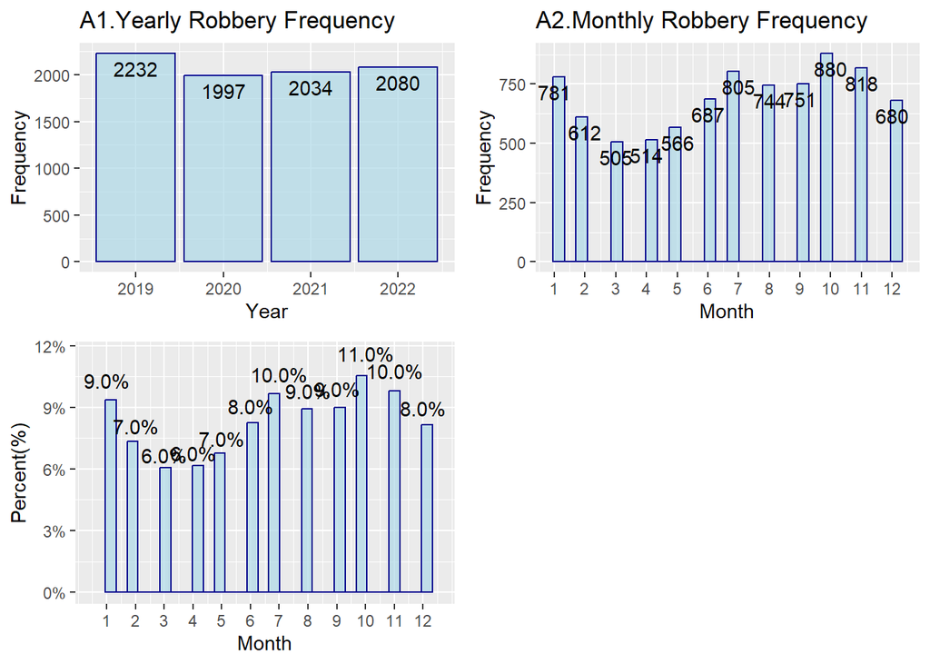

```r
# Plot 1.: Freq by yeqr (x:discrete, Barchart)+Value=count(freq)

plot_year <- ggplot(data=Robbery, aes(x=Year)) +
geom_bar(colour="darkblue", fill="lightblue",alpha = .7) +
geom_text(stat='count', aes(label=..count..),vjust = 1.5) +
  labs(x="Year", y="Frequency") + labs(title="A1.Yearly Robbery Frequency")

# Plot 2.: Freq by yeqr (x:discrete, Barchart)+Value=percent of freq
#plot_year_pct <- ggplot(data=Robbery, aes(x=Year, #y=..count../sum(..count..)*100)) +
#geom_bar(colour="darkblue", fill="lightblue",alpha = .7) + #geom_text(stat='count', aes(label=..count..),vjust = 1.5) + labs(x="Year", #y="Percent(%)") + labs(title="A1.Yearly Robbery Frequency(%)")

# Plot 2.: Freq by Month (x:continuous, Histogram)+Value=count(freq)

plot_Month <- ggplot(data=Robbery, aes(Month)) +
  geom_histogram(col="darkblue",
                 fill="lightblue",
                 alpha = .7) +
  labs(x="Month", y="Frequency") +
  labs(title="A2.Monthly Robbery Frequency") + scale_x_continuous(breaks=1:12) + geom_text(stat='count', aes(label=..count..),vjust = 1.5)

plot_Month_pct <- ggplot(Robbery, aes(x = Month)) +
  geom_histogram(aes(y = after_stat(count / sum(count))), col="darkblue",
                 fill="lightblue",
                 alpha = .7) +
  stat_bin(
    binwidth = 1,geom = "text", color = "black",
    aes(y = after_stat(count / sum(count)),
        label = scales::percent(after_stat(round(count / sum(count), 2)))),
    position = position_stack(vjust = 1.1)
  ) +
  scale_y_continuous(labels = scales::percent)+ scale_x_continuous(breaks=1:12) +
  labs(x="Month", y="Percent(%)","A2.Monthly Robbery Frequency(%)")


grid.arrange(plot_year, plot_Month, plot_Month_pct, ncol=2, nrow=2)
```

The histograms A1~A2 shows the distribution of data over four years (2019-2022) and 12 months within each year. The vertical axis represents the count of data points while the horizontal axis represents the years and months.

This histogram could be used to identify trends and patterns in the data, as well as to determine which months have the most and least data points.

**2-1.Freq by Month :split by pandemic phrases** + Chart A3~A4 show the Robbery frequency by pandemic phrases

```
 (Pre: 14 Month, Lock-down: 17 Month, Post: 17 Month)
```

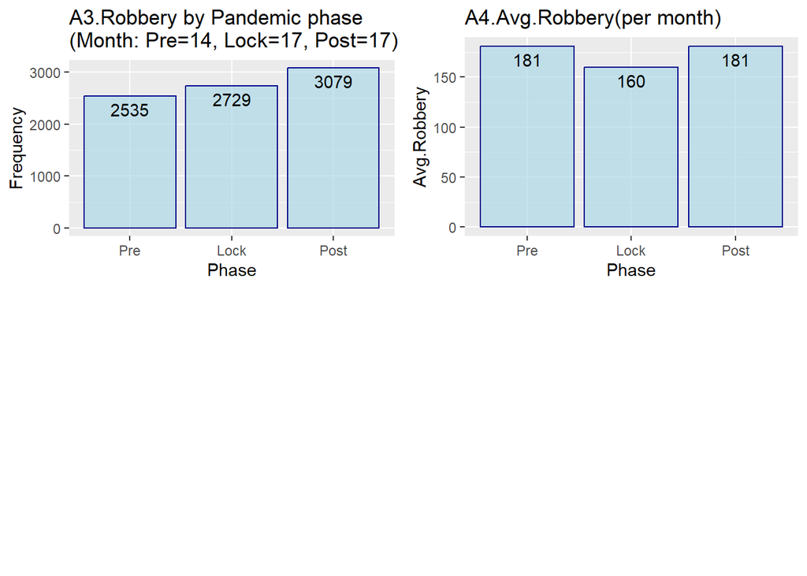

```r
# Plot 3.: Freq by Period phase(Pre,lockdown,post)+Value=count(freq)

plot_Period <- ggplot(data=Robbery, aes(x=Period_cat)) +
geom_bar(colour="darkblue", fill="lightblue",alpha = .7) +
geom_text(stat='count', aes(label=..count..), vjust = 1.5) +
  labs(x="Phase", y="Frequency") + labs(title="A3.Robbery by Pandemic phase
(Month: Pre=14, Lock=17, Post=17)")


###################################
# Plot 4. average Robbery frequency per month [by Period_cat]+Value
temp <- count(Robbery,Period_cat, sort=TRUE)

#Avg
temp[1,3] = as.integer(temp[1,2] / 17 ) #post: 17M
temp[2,3] = as.integer(temp[2,2] / 17) #lock: 17M
temp[3,3] = as.integer(temp[3,2] / 14) #pre: 14M

x <-  c("Pre","Lock","Post")
y  <-  c(temp[3,3],temp[2,3],temp[1,3] )

temp_2 <- data.frame(x,y)
#barplot(y, names.arg = x)

plot_Period_mon <- ggplot(data=temp_2, aes(x,y)) +
  geom_bar(col="darkblue",
                 fill="lightblue",
                 alpha = .7,stat='identity') +
  labs(x="Phase", y="Avg.Robbery") +
  labs(title="A4.Avg.Robbery(per month)") + scale_x_discrete(limits=c("Pre","Lock","Post")) + geom_text(aes(label=signif(y)),vjust = 1.5)

grid.arrange(plot_Period, plot_Period_mon, ncol=2, nrow=2)
```

Based on the provided data, A3 and A4 show the frequency of robbery incidents split by pandemic phases. The pandemic phases are divided into three categories, which are pre-pandemic, lock-down, and post-pandemic.

A3 shows the number of robbery incidents that occurred during each of the pandemic phases. The pre-pandemic phase had 2535 robbery incidents, the lock-down phase had 2729 robbery incidents, and the post-pandemic phase had 3079 robbery incidents.

A4 shows the average number of robbery incidents per month during each pandemic phase. The pre-pandemic phase had an average of 181 robbery incidents per month, the lock-down phase had an average of 160 robbery incidents per month, and the post-pandemic phase had an average of 181 robbery incidents per month.

Overall, the data shows that there was an increase in the number of robbery incidents during the lock-down phase compared to the pre-pandemic phase. However, the number of robbery incidents during the post-pandemic phase was higher than both the pre-pandemic and lock-down phases. The average number of robbery incidents per month remained relatively stable during the pre-pandemic and post-pandemic phases, but decreased during the lock-down phase.

```r
#1. by pandemic phrases
Robbery_pre <- subset(Robbery,subset = Robbery$Period_cat == 'Pre')  #2535
Robbery_lock <- subset(Robbery,subset = Robbery$Period_cat == 'Lock') #2729
Robbery_post <- subset(Robbery,subset = Robbery$Period_cat == 'Post') #3079

#2. by year
Robbery_2019 <- subset(Robbery,subset = Robbery$Year == 2019)  #2574
Robbery_2020 <- subset(Robbery,subset = Robbery$Year == 2020) #2648
Robbery_2021 <- subset(Robbery,subset = Robbery$Year == 2021)
Robbery_2022 <- subset(Robbery,subset = Robbery$Year == 2022)
```

- Chart A2-2~A2-4 show the Monthly Robbery frequency by pandemic phrases

  (Total: Chart A2.Monthly Robbery Frequency)

```r
#Same as Chart A2 (Skip)

#Sum of 4years (2019~2022)
#plot_Month <- ggplot(data=Robbery, aes(Month)) +
#  geom_histogram(col="darkblue",
#                 fill="lightblue",
#                 alpha = .7) +
#  labs(x="Month", y="Frequency") +
#  labs(title="A2-1.Monthly Robbery frequency") + scale_x_continuous(breaks=1:12) + #geom_text(stat='count', aes(label=..count..),vjust = 1.5)

#plot_Month
```

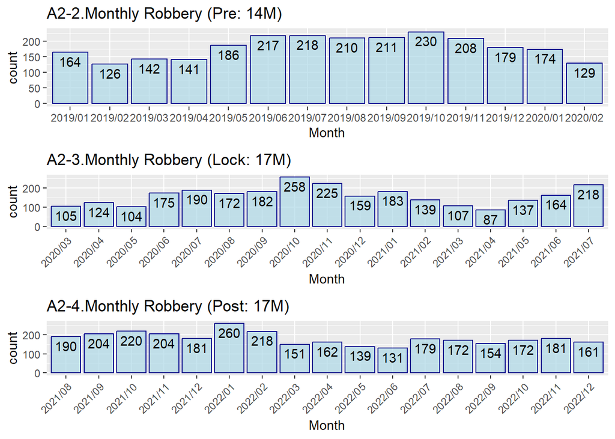

```r
# Plot.Freq by Month :split by pandemic phrase

#pre
plot_Month_pre <- ggplot(data=Robbery_pre, aes(x=Month_3)) +
geom_bar(colour="darkblue", fill="lightblue",alpha = .7) +
geom_text(stat='count', aes(label=..count..),vjust = 1.4) + #vjust:lable position
  labs(x="Month") + labs(title="A2-2.Monthly Robbery (Pre: 14M)")

#lock
plot_Month_lock <- ggplot(data=Robbery_lock, aes(x=Month_3)) +
geom_bar(colour="darkblue", fill="lightblue",alpha = .7) +
geom_text(stat='count', aes(label=..count..),vjust = 1.4) + #vjust:lable position
  labs(x="Month") + labs(title="A2-3.Monthly Robbery (Lock: 17M)") + theme(axis.text.x = element_text(angle = 45, vjust = 1, hjust=1))

#post
plot_Month_post <- ggplot(data=Robbery_post, aes(x=Month_3)) +
geom_bar(colour="darkblue", fill="lightblue",alpha = .7) +
geom_text(stat='count', aes(label=..count..),vjust = 1.4) + #vjust:lable position
  labs(x="Month") + labs(title="A2-4.Monthly Robbery (Post: 17M)") + theme(axis.text.x = element_text(angle = 45, vjust = 1, hjust=1))

grid.arrange(plot_Month_pre, plot_Month_lock,plot_Month_post, ncol=1, nrow=3)
```

This histograms shows the monthly robbery frequency during three different periods: pre-pandemic (A2-2), lockdown (A2-3), and post-pandemic (A2-4). The pre-pandemic period covers 14 months from January 2019 to February 2020. The lockdown period covers 17 months from March 2020 to July 2021. The post-pandemic period covers 17 months from August 2021 to December 2022.

Looking at the histograms, the monthly robbery frequency during the pre-pandemic period ranged from 126 to 230 incidents, with an average of 181 incidents per month. During the lockdown period, the monthly robbery frequency ranged from 87 to 258 incidents, with an average of 160 incidents per month. Finally, during the post-pandemic period, the monthly robbery frequency ranged from 131 to 260 incidents, with an average of 181 incidents per month.

```r
# Plot.Freq by Month(percent %) :split by pandemic phrase
```

```
#> Skip(if we need, can add)
```

```r
#pre
#plot_Month_pre_pct <- ggplot(data=Robbery_pre, aes(x=Month_3, y=..count../sum(..count..)*100)) + geom_bar(colour="darkblue", fill="lightblue",alpha = .7) + geom_text(stat='count', aes(label=..count..),vjust = 1.5) + labs(x="Month", y="Percent(%)") + labs(title="A2-2.Monthly Robbery (Pre, %)") + theme(axis.text.x = element_text(angle = 45, vjust = 1, hjust=1))

#lock
#plot_Month_lock_pct <- ggplot(data=Robbery_lock, aes(x=Month_3, y=..count../sum(..count..)*100)) + geom_bar(colour="darkblue", fill="lightblue",alpha = .7) + geom_text(stat='count', aes(label=..count..),vjust = 1.5) + labs(x="Month", y="Percent(%)") + labs(title="A2-3.Monthly Robbery (lock, %)") + theme(axis.text.x = element_text(angle = 45, vjust = 1, hjust=1))


#plot_Month_post_pct <- ggplot(data=Robbery_post, aes(x=Month_3, y=..count../sum(..count..)*100)) + geom_bar(colour="darkblue", fill="lightblue",alpha = .7) + geom_text(stat='count', aes(label=..count..),vjust = 1.5) + labs(x="Month", y="Percent(%)") + labs(title="A2-4.Monthly Robbery (post, %)") + theme(axis.text.x = element_text(angle = 45, vjust = 1, hjust=1))

#grid.arrange(plot_Month_pre_pct, plot_Month_lock_pct,plot_Month_post_pct, ncol=1, nrow=3)
```

**2-2. Freq by Month :split by Years**

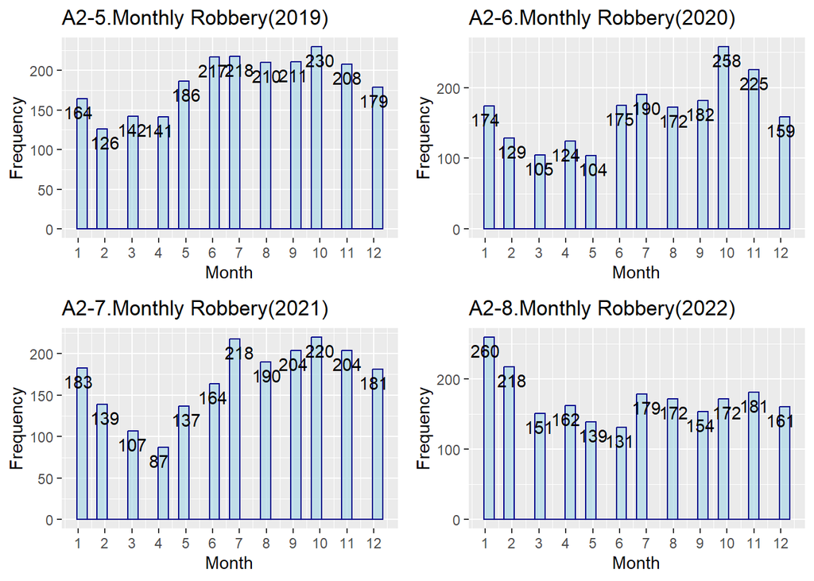

```r
# Plot.Freq by Month :split by pandemic phrase

plot_Month_2019 <- ggplot(data=Robbery_2019, aes(Month)) +
  geom_histogram(col="darkblue",
                 fill="lightblue",
                 alpha = .7) +
  labs(x="Month", y="Frequency") +
  labs(title="A2-5.Monthly Robbery(2019)") + scale_x_continuous(breaks=1:12) + geom_text(stat='count', aes(label=..count..),vjust = 1.5)


plot_Month_2020 <- ggplot(data=Robbery_2020, aes(Month)) +
  geom_histogram(col="darkblue",
                 fill="lightblue",
                 alpha = .7) +
  labs(x="Month", y="Frequency") +
  labs(title="A2-6.Monthly Robbery(2020)") + scale_x_continuous(breaks=1:12) + geom_text(stat='count', aes(label=..count..),vjust = 1.5)

plot_Month_2021 <- ggplot(data=Robbery_2021, aes(Month)) +
  geom_histogram(col="darkblue",
                 fill="lightblue",
                 alpha = .7) +
  labs(x="Month", y="Frequency") +
  labs(title="A2-7.Monthly Robbery(2021)") + scale_x_continuous(breaks=1:12) + geom_text(stat='count', aes(label=..count..),vjust = 1.5)

plot_Month_2022 <- ggplot(data=Robbery_2022, aes(Month)) +
  geom_histogram(col="darkblue",
                 fill="lightblue",
                 alpha = .7) +
  labs(x="Month", y="Frequency") +
  labs(title="A2-8.Monthly Robbery(2022)") + scale_x_continuous(breaks=1:12) + geom_text(stat='count', aes(label=..count..),vjust = 1.5)

grid.arrange(plot_Month_2019, plot_Month_2020,plot_Month_2021, plot_Month_2022, ncol=2, nrow=2)
```

The bar charts (A2-5, A2-6, A2-7, A2-8) display the number of robberies per month and year, with the x-axis representing the months and the y-axis representing the frequency of robberies. These charts provide valuable insights into the trends and patterns in robbery incidents over a four-year period.

```r
#X-axis order check
#temp <- count(Robbery,Season, sort=FALSE)
#temp

#temp <- count(Robbery_pre,Season, sort=FALSE) #fall, summer, winter, spring
#temp

#temp <- count(Robbery_lock,Season, sort=FALSE) #fall, summer, winter, spring
#temp

#temp <- count(Robbery_post,Season, sort=FALSE) #fall, summer, winter, spring
#temp
```

**3-1. Freq by Season :split by pandemic phrases (Avg.Robbery(per month)**

The data is split into four categories based on the season: Spring, Summer, Autumn, and Winter. The average number of robberies per month is calculated for each season.

The data is then split into three categories based on pandemic phrases: Pre-pandemic, Lockdown, and Post-pandemic. The average number of robberies per month is calculated for each pandemic phase.

- Chart B1_2 (lockdown)

At the beginning of lock-down(spring,summer) decreased.

From AUTUMN, robbery dramatically increased again and continued to increase after finishing lock-down

Pattern of post pandemic is interesting(Summer, Winter)

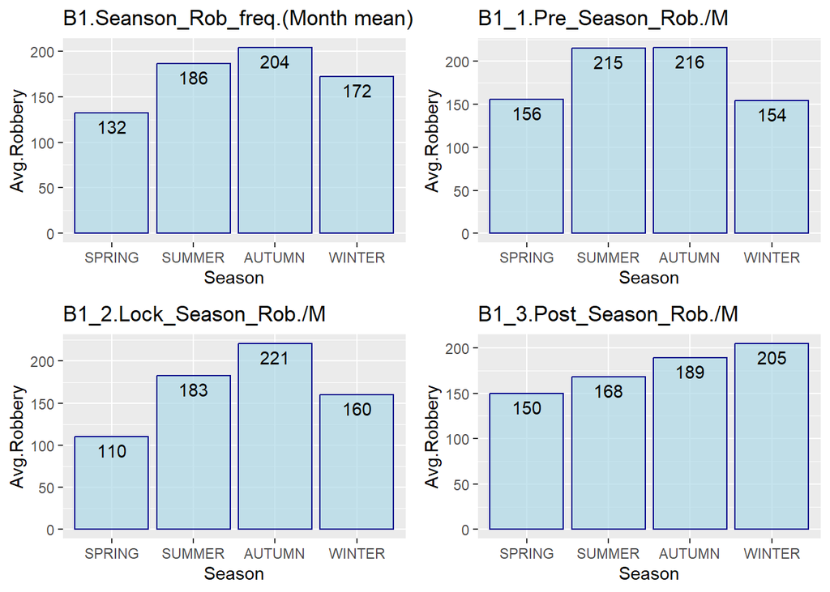

```r
# Number of months per each season of pandemic phrases
#      pre  lock    post  total
#spring 3      6      3     12
#sum    3      5      4     12
#fall   3      3      6     12
#winter 5      3      4     12
#        14   17     17     48

#Total
temp <- count(Robbery,Season, sort=FALSE) #spring, summer,AUTUMN, winter,

#total_Avg
temp[1,3] = as.integer(temp[1,2] / 12) #spring
temp[2,3] = as.integer(temp[2,2] / 12) #summer
temp[3,3] = as.integer(temp[3,2] / 12) #AUTUMN
temp[4,3] = as.integer(temp[4,2] / 12) #winter

x <-  c("SPRING","SUMMER","AUTUMN","WINTER")
y  <-  c(temp[1,3],temp[2,3],temp[3,3],temp[4,3] )

temp_2 <- data.frame(x,y)
#barplot(y, names.arg = x)

plot_Season <- ggplot(data=temp_2, aes(x,y)) +
  geom_bar(col="darkblue",
                 fill="lightblue",
                 alpha = .7,stat='identity') +
  labs(x="Season", y="Avg.Robbery") +
  labs(title="B1.Seanson_Rob_freq.(Month mean)") + scale_x_discrete(limits=c("SPRING","SUMMER","AUTUMN","WINTER")) + geom_text(aes(label=signif(y)),vjust = 1.5)

#########Pre
temp <- count(Robbery_pre,Season, sort=FALSE)

#pre-pen
temp[1,3] = as.integer(temp[1,2] / 3) # spring
temp[2,3] = as.integer(temp[2,2] / 3) # summer
temp[3,3] = as.integer(temp[3,2] / 3) # AUTUMN
temp[4,3] = as.integer(temp[4,2] / 5) # winter

x <-  c("SPRING","SUMMER","AUTUMN","WINTER")
y  <-  c(temp[1,3],temp[2,3],temp[3,3],temp[4,3] )

temp_2 <- data.frame(x,y)
#barplot(y, names.arg = x)

plot_Season_pre <- ggplot(data=temp_2, aes(x,y)) +
  geom_bar(col="darkblue",
                 fill="lightblue",
                 alpha = .7,stat='identity') +
  labs(x="Season", y="Avg.Robbery") +
  labs(title="B1_1.Pre_Season_Rob./M") + scale_x_discrete(limits=c("SPRING","SUMMER","AUTUMN","WINTER")) + geom_text(aes(label=signif(y)),vjust = 1.5)


######Lock
temp <- count(Robbery_lock,Season, sort=FALSE)

#lock-pen
temp[1,3] = as.integer(temp[1,2] / 6) # spring
temp[2,3] = as.integer(temp[2,2] / 5) # summer
temp[3,3] = as.integer(temp[3,2] / 3) # AUTUMN
temp[4,3] = as.integer(temp[4,2] / 3) # winter

x <-  c("SPRING","SUMMER","AUTUMN","WINTER")
y  <-  c(temp[1,3],temp[2,3],temp[3,3],temp[4,3] )

temp_2 <- data.frame(x,y)
#barplot(y, names.arg = x)

plot_Season_lock <- ggplot(data=temp_2, aes(x,y)) +
  geom_bar(col="darkblue",
                 fill="lightblue",
                 alpha = .7,stat='identity') +
  labs(x="Season", y="Avg.Robbery") +
  labs(title="B1_2.Lock_Season_Rob./M") + scale_x_discrete(limits=c("SPRING","SUMMER","AUTUMN","WINTER")) + geom_text(aes(label=signif(y)),vjust = 1.5)

#########Post
temp <- count(Robbery_post,Season, sort=FALSE) #fall, summer, winter, spring

#post-pen
temp[1,3] = as.integer(temp[1,2] / 3) # spring
temp[2,3] = as.integer(temp[2,2] / 4) # summer
temp[3,3] = as.integer(temp[3,2] / 6) # AUTUMN
temp[4,3] = as.integer(temp[4,2] / 4) # winter

x <-  c("SPRING","SUMMER","AUTUMN","WINTER")
y  <-  c(temp[1,3],temp[2,3],temp[3,3],temp[4,3] )

temp_2 <- data.frame(x,y)
#barplot(y, names.arg = x)

plot_Season_post <- ggplot(data=temp_2, aes(x,y)) +
  geom_bar(col="darkblue",
                 fill="lightblue",
                 alpha = .7,stat='identity') +
  labs(x="Season", y="Avg.Robbery") +
  labs(title="B1_3.Post_Season_Rob./M") + scale_x_discrete(limits=c("SPRING","SUMMER","AUTUMN","WINTER")) + geom_text(aes(label=signif(y)),vjust = 1.5)

grid.arrange(plot_Season, plot_Season_pre, plot_Season_lock, plot_Season_post,
             ncol=2, nrow=2)
```

Chart B1_3 shows the average number of robberies per month in each season after the lockdown period. The number of robberies in summer decreased slightly to an average of 168, while the number of robberies in autumn remained high at an average of 189. The number of robberies in spring increased to an average of 150, while the number of robberies in winter increased significantly to an average of 205.

**3-2. Freq by Season :split by Years**

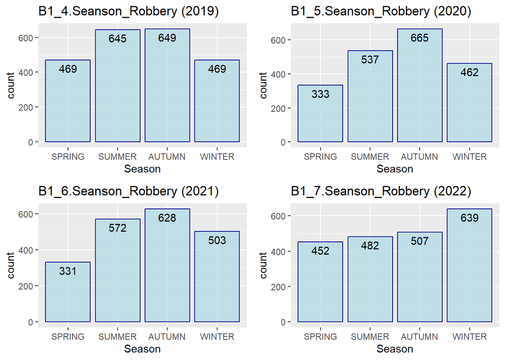

```r
plot_Season_2019 <- ggplot(data=Robbery_2019, aes(x=Season)) +
geom_bar(colour="darkblue", fill="lightblue",alpha = .7) +
geom_text(stat='count', aes(label=..count..),vjust = 1.5) + scale_x_discrete(limits=c("SPRING","SUMMER","AUTUMN","WINTER")) +
  labs(x="Season") + labs(title="B1_4.Seanson_Robbery (2019)")

plot_Season_2020 <- ggplot(data=Robbery_2020, aes(x=Season)) +
geom_bar(colour="darkblue", fill="lightblue",alpha = .7) +
geom_text(stat='count', aes(label=..count..),vjust = 1.5) + scale_x_discrete(limits=c("SPRING","SUMMER","AUTUMN","WINTER")) +
  labs(x="Season") + labs(title="B1_5.Seanson_Robbery (2020)")

plot_Season_2021 <- ggplot(data=Robbery_2021, aes(x=Season)) +
geom_bar(colour="darkblue", fill="lightblue",alpha = .7) +
geom_text(stat='count', aes(label=..count..),vjust = 1.5) + scale_x_discrete(limits=c("SPRING","SUMMER","AUTUMN","WINTER")) +
  labs(x="Season") + labs(title="B1_6.Seanson_Robbery (2021)")

plot_Season_2022 <- ggplot(data=Robbery_2022, aes(x=Season)) +
geom_bar(colour="darkblue", fill="lightblue",alpha = .7) +
geom_text(stat='count', aes(label=..count..),vjust = 1.5) + scale_x_discrete(limits=c("SPRING","SUMMER","AUTUMN","WINTER")) +
  labs(x="Season") + labs(title="B1_7.Seanson_Robbery (2022)")


grid.arrange(plot_Season_2019, plot_Season_2020, plot_Season_2021, plot_Season_2022,
             ncol=2, nrow=2)
```

These charts reveal that the average number of robberies per month varied across different years and seasons. The highest averages were not consistently in the same season or year.

Overall, the data suggests that the pandemic had a significant impact on the average number of robberies per month, particularly during the lockdown period. However, it’s important to note that there were also fluctuations in the data across different seasons and years, indicating that other factors may also be contributing to the frequency of robberies.

**4-1. Freq by Date_cat(Begin,Middle,End) :split by pandemic phrases**

In this analysis, the number of robberies is split by date categories: begin, middle, and end of each month. The data is also split by pandemic phrases, to examine any potential impact of the pandemic on robbery frequency.

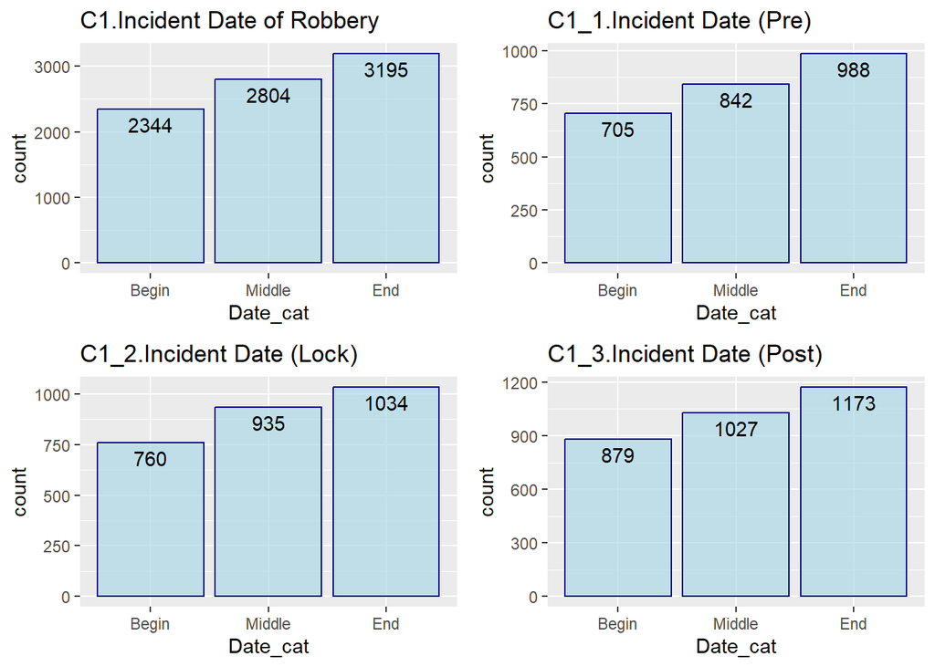

```r
plot_Date_cat <- ggplot(data=Robbery, aes(x=Date_cat)) +
geom_bar(colour="darkblue", fill="lightblue",alpha = .7) +
geom_text(stat='count', aes(label=..count..),vjust = 1.5) + scale_x_discrete(limits=c("Begin","Middle","End")) +
  labs(x="Date_cat") + labs(title="C1.Incident Date of Robbery")

plot_Date_cat_pre <- ggplot(data=Robbery_pre, aes(Date_cat)) +
geom_bar(colour="darkblue", fill="lightblue",alpha = .7) +
geom_text(stat='count', aes(label=..count..),vjust = 1.5) + scale_x_discrete(limits=c("Begin","Middle","End")) +
  labs(x="Date_cat") + labs(title="C1_1.Incident Date (Pre)")

plot_Date_cat_lock <- ggplot(data=Robbery_lock, aes(Date_cat)) +
geom_bar(colour="darkblue", fill="lightblue",alpha = .7) +
geom_text(stat='count', aes(label=..count..),vjust = 1.5) + scale_x_discrete(limits=c("Begin","Middle","End")) +
  labs(x="Date_cat") + labs(title="C1_2.Incident Date (Lock)")

plot_Date_cat_post <- ggplot(data=Robbery_post, aes(Date_cat)) +
geom_bar(colour="darkblue", fill="lightblue",alpha = .7) +
geom_text(stat='count', aes(label=..count..),vjust = 1.5) + scale_x_discrete(limits=c("Begin","Middle","End")) +
  labs(x="Date_cat") + labs(title="C1_3.Incident Date (Post)")

grid.arrange(plot_Date_cat, plot_Date_cat_pre, plot_Date_cat_lock, plot_Date_cat_post,
             ncol=2, nrow=2)
```

The chart C1 shows the number of robbery incidents based on the date category. The data is split into three categories: Begin, Middle, and End.

From the chart, we can see that the highest number of robbery incidents occurred during the End category, followed by the Middle category and the Begin category.

[Percent,%] Freq by Date_cat(Begin,Middle,End) :split by pandemic phrases

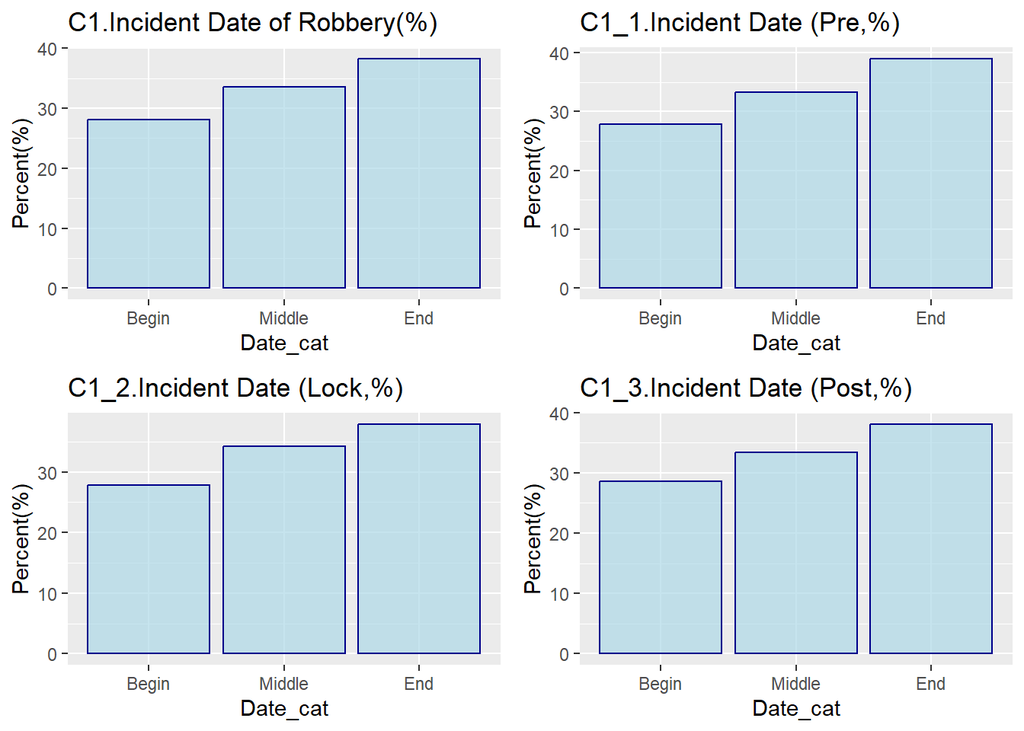

```r
plot_Date_cat_pct <- ggplot(data=Robbery, aes(x=Date_cat,y=..count../sum(..count..)*100)) +
geom_bar(colour="darkblue", fill="lightblue",alpha = .7) +
scale_x_discrete(limits=c("Begin","Middle","End")) +
  labs(x="Date_cat", y="Percent(%)") + labs(title="C1.Incident Date of Robbery(%)")

plot_Date_cat_pre_pct <- ggplot(data=Robbery_pre, aes(x=Date_cat,y=..count../sum(..count..)*100)) +
geom_bar(colour="darkblue", fill="lightblue",alpha = .7) +
scale_x_discrete(limits=c("Begin","Middle","End")) +
  labs(x="Date_cat", y="Percent(%)") + labs(title="C1_1.Incident Date (Pre,%)")

plot_Date_cat_lock_pct <- ggplot(data=Robbery_lock, aes(x=Date_cat,y=..count../sum(..count..)*100)) +
geom_bar(colour="darkblue", fill="lightblue",alpha = .7) +
scale_x_discrete(limits=c("Begin","Middle","End")) +
  labs(x="Date_cat", y="Percent(%)") + labs(title="C1_2.Incident Date (Lock,%)")

plot_Date_cat_post_pct <- ggplot(data=Robbery_post, aes(x=Date_cat,y=..count../sum(..count..)*100)) +
geom_bar(colour="darkblue", fill="lightblue",alpha = .7) +
scale_x_discrete(limits=c("Begin","Middle","End")) +
  labs(x="Date_cat", y="Percent(%)") + labs(title="C1_3.Incident Date (Post,%)")

grid.arrange(plot_Date_cat_pct, plot_Date_cat_pre_pct, plot_Date_cat_lock_pct, plot_Date_cat_post_pct,
             ncol=2, nrow=2)
```

**4-2. Boxplot distribution of date :split by pandemic phrases**

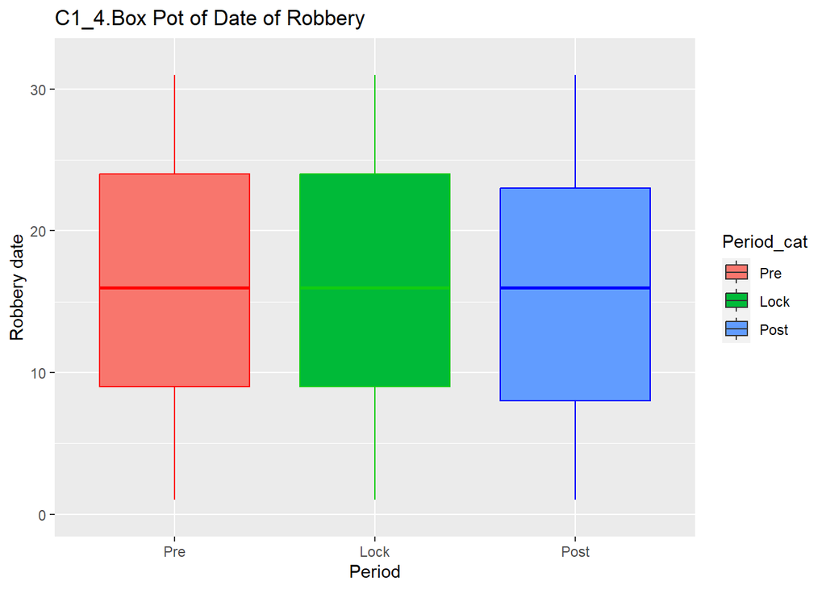

```r
boxplot_Date <- ggplot(Robbery, aes(y=Date, x=Period_cat, fill=Period_cat)) +
  geom_boxplot() +
  geom_boxplot( colour=c("#ff0000","#11cc11","#0000ff"), outlier.shape=8,
                outlier.colour="lightblue", outlier.size=4) +  labs(title="C1_4.Box Pot of Date of Robbery", x="Period", y = "Robbery date") + ylim(0,32)

boxplot_Date
```

The boxplot shows the distribution of robbery incidents across three different time periods: pre-pandemic, lockdown, and post-pandemic. The median robbery date for each period is represented by the horizontal line within each box, while the lower and upper boundaries of the box represent the 25th and 75th percentiles, respectively.

Looking at the plot, we can see that the distribution of robbery incidents is relatively similar across the different periods. The boxes for each period have similar widths and heights, indicating similar variability and spread of the data within each period.

**5-1. Freq by SHIFT(DAY,EVENING,MIDNIGHT) :split by pandemic phrases**

This section examines the frequency of robberies during different shifts of the day: Day, Evening, and Midnight. The data is categorized based on three pandemic phases: Pre-pandemic, Lockdown, and Post-pandemic. The analysis is based on the count of robberies, rather than the average number of robberies per month. This analysis provides insight into the impact of pandemic phases on the occurrence of robberies at various times of the day.

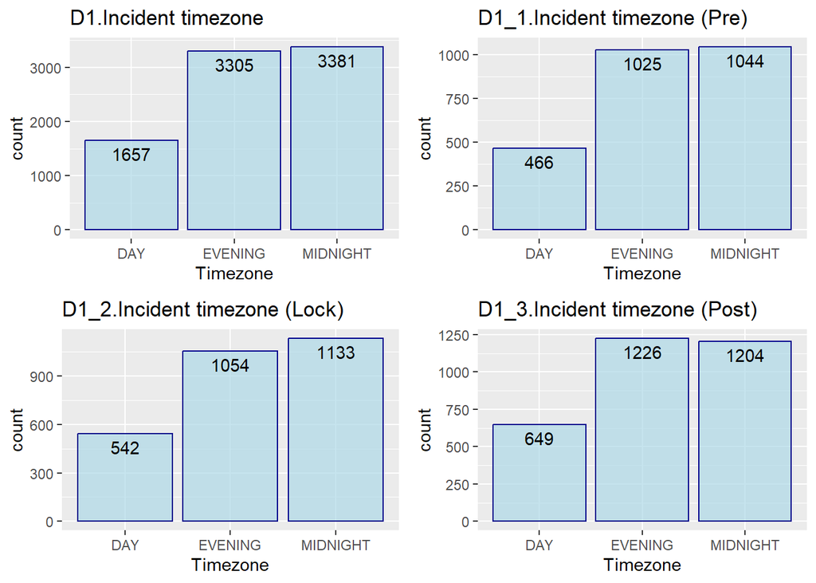

```r
# Bar plot

plot_SHIFT <- ggplot(data=Robbery, aes(x=SHIFT)) +
geom_bar(colour="darkblue", fill="lightblue",alpha = .7) +
geom_text(stat='count', aes(label=..count..),vjust = 1.5) + scale_x_discrete(limits=c("DAY","EVENING","MIDNIGHT")) +
  labs(x="Timezone") + labs(title="D1.Incident timezone")

plot_SHIFT_pre <- ggplot(data=Robbery_pre, aes(SHIFT)) +
geom_bar(colour="darkblue", fill="lightblue",alpha = .7) +
geom_text(stat='count', aes(label=..count..),vjust = 1.5) + scale_x_discrete(limits=c("DAY","EVENING","MIDNIGHT")) +
  labs(x="Timezone") + labs(title="D1_1.Incident timezone (Pre)")

plot_SHIFT_lock <- ggplot(data=Robbery_lock, aes(SHIFT)) +
geom_bar(colour="darkblue", fill="lightblue",alpha = .7) +
geom_text(stat='count', aes(label=..count..),vjust = 1.5) + scale_x_discrete(limits=c("DAY","EVENING","MIDNIGHT")) +
  labs(x="Timezone") + labs(title="D1_2.Incident timezone (Lock)")

plot_SHIFT_post <- ggplot(data=Robbery_post, aes(SHIFT)) +
geom_bar(colour="darkblue", fill="lightblue",alpha = .7) +
geom_text(stat='count', aes(label=..count..),vjust = 1.5) + scale_x_discrete(limits=c("DAY","EVENING","MIDNIGHT")) +
  labs(x="Timezone") + labs(title="D1_3.Incident timezone (Post)")

grid.arrange(plot_SHIFT, plot_SHIFT_pre, plot_SHIFT_lock, plot_SHIFT_post,
             ncol=2, nrow=2)
```

Overall, the number of robberies was highest during the Midnight shift, with 3381 incidents reported, followed by 3305 in the Evening and 1657 during the Day shift. During the Pre-pandemic phase, the highest number of robberies occurred during the Midnight shift, with 1044 incidents, while in the Lockdown phase, the Midnight shift had the highest number of robberies, with 1133 incidents. In the Post-pandemic phase, the Evening shift had the highest number of robberies, with 1226 incidents reported with a decrease in Midnight shift.

This analysis can help in identifying the high-risk periods for robbery and can assist law enforcement agencies in allocating resources to ensure public safety. It can also help in understanding the impact of pandemic phases on the incidence of robbery at different times of the day.

[Percent,%] Freq by SHIFT(DAY,EVENING,MIDNIGHT) :split by pandemic phrases

- Portion of Day (Pre-Lock-Post): 18.4% 19.9% 21.1%
- Portion of EVENING (Pre-Lock-Post): 40.4% 38.6% 39.8%
- Portion of MIDNIGHT (Pre-Lock-Post): 41.2% 41.5% 39.1%

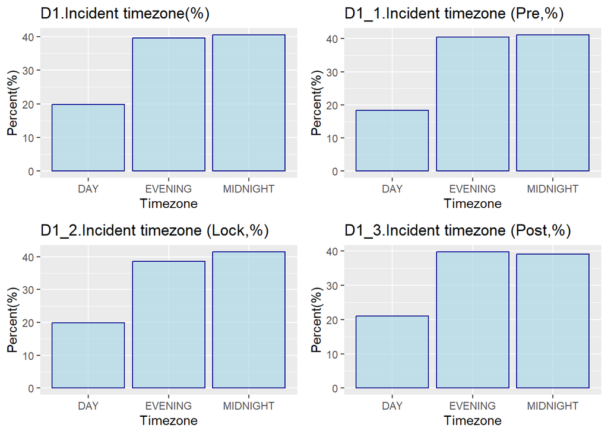

```r
# Bar plot

plot_SHIFT_pct <- ggplot(data=Robbery, aes(x=SHIFT,y=..count../sum(..count..)*100)) +
geom_bar(colour="darkblue", fill="lightblue",alpha = .7) +
scale_x_discrete(limits=c("DAY","EVENING","MIDNIGHT")) +
  labs(x="Timezone", y="Percent(%)") + labs(title="D1.Incident timezone(%)")


plot_SHIFT_pre_pct <- ggplot(data=Robbery_pre, aes(x=SHIFT,y=..count../sum(..count..)*100)) + geom_bar(colour="darkblue", fill="lightblue",alpha = .7) +
scale_x_discrete(limits=c("DAY","EVENING","MIDNIGHT")) +
  labs(x="Timezone", y="Percent(%)") + labs(title="D1_1.Incident timezone (Pre,%)")

plot_SHIFT_lock_pct <- ggplot(data=Robbery_lock, aes(x=SHIFT,y=..count../sum(..count..)*100)) +
geom_bar(colour="darkblue", fill="lightblue",alpha = .7) +
scale_x_discrete(limits=c("DAY","EVENING","MIDNIGHT")) +
  labs(x="Timezone", y="Percent(%)") + labs(title="D1_2.Incident timezone (Lock,%)")

plot_SHIFT_post_pct <- ggplot(data=Robbery_post, aes(x=SHIFT,y=..count../sum(..count..)*100)) +
geom_bar(colour="darkblue", fill="lightblue",alpha = .7) +
scale_x_discrete(limits=c("DAY","EVENING","MIDNIGHT")) +
  labs(x="Timezone", y="Percent(%)") + labs(title="D1_3.Incident timezone (Post,%)")

grid.arrange(plot_SHIFT_pct, plot_SHIFT_pre_pct, plot_SHIFT_lock_pct, plot_SHIFT_post_pct,
             ncol=2, nrow=2)
```

The analysis of the data shows that during the day time, the percentage of robberies was consistent at around 20% across all three periods: pre-pandemic, lockdown, and post-pandemic. However, in the evening and midnight time periods, the percentage of robberies was consistently higher, at almost 40% for each period.

**5-2. Boxplot distribution of Time_hour(00:00~24:00) :split by pandemic phrases**

The boxplot distribution of time_hour split by pandemic phases provides an insight into the distribution of the time of the day when the robbery incidents occurred in different pandemic periods.

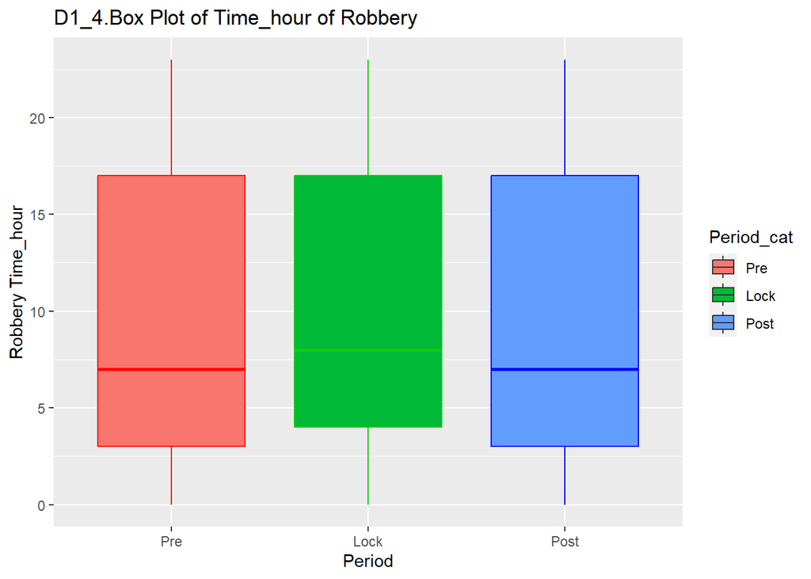

```r
boxplot_Time_hour <- ggplot(Robbery, aes(y=Time_hour, x=Period_cat, fill=Period_cat)) +
  geom_boxplot() +
  geom_boxplot( colour=c("#ff0000","#11cc11","#0000ff"), outlier.shape=8,
                outlier.colour="lightblue", outlier.size=4) +  labs(title="D1_4.Box Plot of Time_hour of Robbery", x="Period", y = "Robbery Time_hour") + ylim(0,23)

boxplot_Time_hour
```

**6-1. Freq by Day_cat (Sun~Sat) :split by pandemic phrases**

This section presents a frequency analysis of robbery incidents by day of the week, split by pandemic phases. The days of the week are categorized as Sunday to Saturday. The purpose of this analysis is to determine if there were any changes in the frequency of robbery incidents on specific days of the week during the pandemic phases.

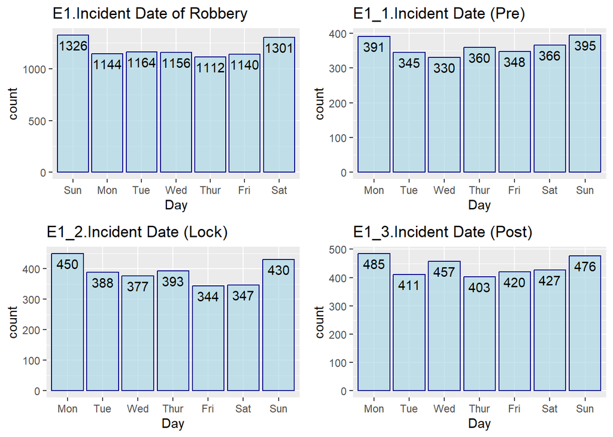

```r
# Bar plot

plot_Day_cat<- ggplot(data=Robbery, aes(x=Day_cat)) +
geom_bar(colour="darkblue", fill="lightblue",alpha = .7) +
geom_text(stat='count', aes(label=..count..),vjust = 1.5) + scale_x_discrete(limits=c("Sun","Mon","Tue","Wed","Thur","Fri","Sat")) +
  labs(x="Day") + labs(title="E1.Incident Date of Robbery")

plot_Day_cat_pre <- ggplot(data=Robbery_pre, aes(Day_cat)) +
geom_bar(colour="darkblue", fill="lightblue",alpha = .7) +
geom_text(stat='count', aes(label=..count..),vjust = 1.5) + scale_x_discrete(limits=c("Mon","Tue","Wed","Thur","Fri","Sat","Sun")) +
  labs(x="Day") + labs(title="E1_1.Incident Date (Pre)")

plot_Day_cat_lock <- ggplot(data=Robbery_lock, aes(Day_cat)) +
geom_bar(colour="darkblue", fill="lightblue",alpha = .7) +
geom_text(stat='count', aes(label=..count..),vjust = 1.5) + scale_x_discrete(limits=c("Mon","Tue","Wed","Thur","Fri","Sat","Sun")) +
  labs(x="Day") + labs(title="E1_2.Incident Date (Lock)")

plot_Day_cat_post <- ggplot(data=Robbery_post, aes(Day_cat)) +
geom_bar(colour="darkblue", fill="lightblue",alpha = .7) +
geom_text(stat='count', aes(label=..count..),vjust = 1.5) + scale_x_discrete(limits=c("Mon","Tue","Wed","Thur","Fri","Sat","Sun")) +
  labs(x="Day") + labs(title="E1_3.Incident Date (Post)")

grid.arrange(plot_Day_cat, plot_Day_cat_pre, plot_Day_cat_lock, plot_Day_cat_post,
             ncol=2, nrow=2)
```

These four histograms show the frequency of robberies that occurred on each day of the week during different periods: overall, pre-pandemic, lockdown, and post-pandemic.

Looking at the overall histogram, we can see that Sunday had the highest frequency of robberies, with 1326 incidents reported, while Thursday had the lowest frequency, with only 1112 incidents reported. The remaining days had frequencies that were relatively close to each other.

**7-1. Freq by Day_cat_2 (Week,Weekend) :split by pandemic phrases**

The section 7-1 shows the frequency of robberies based on two categories: weekdays and weekends. The data is also split by pandemic phrases: pre, lock, and post.

- Portion of Weekend (Pre-Lock-Post): 31.01% 32.25% 31.21%

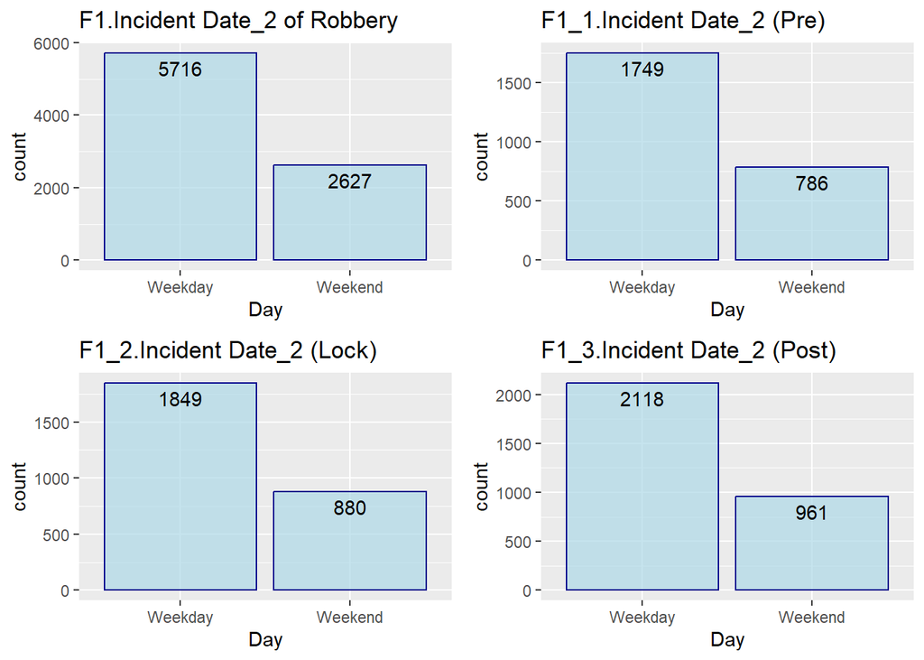

```r
# Bar plot

plot_Day_cat_2<- ggplot(data=Robbery, aes(x=Day_cat_2)) +
geom_bar(colour="darkblue", fill="lightblue",alpha = .7) +
geom_text(stat='count', aes(label=..count..),vjust = 1.5) + labs(x="Day") +
  labs(title="F1.Incident Date_2 of Robbery")

plot_Day_cat_2_pre <- ggplot(data=Robbery_pre, aes(Day_cat_2)) +
geom_bar(colour="darkblue", fill="lightblue",alpha = .7) +
geom_text(stat='count', aes(label=..count..),vjust = 1.5) +labs(x="Day") +
  labs(title="F1_1.Incident Date_2 (Pre)")

plot_Day_cat_2_lock <- ggplot(data=Robbery_lock, aes(Day_cat_2)) +
geom_bar(colour="darkblue", fill="lightblue",alpha = .7) +
geom_text(stat='count', aes(label=..count..),vjust = 1.5) + labs(x="Day") +
  labs(title="F1_2.Incident Date_2 (Lock)")

plot_Day_cat_2_post <- ggplot(data=Robbery_post, aes(Day_cat_2)) +
geom_bar(colour="darkblue", fill="lightblue",alpha = .7) +
geom_text(stat='count', aes(label=..count..),vjust = 1.5) + labs(x="Day") +
  labs(title="F1_3.Incident Date_2 (Post)")

grid.arrange(plot_Day_cat_2, plot_Day_cat_2_pre, plot_Day_cat_2_lock, plot_Day_cat_2_post,
             ncol=2, nrow=2)
```

The histograms show the frequency of robberies on weekdays and weekends in different periods. In the overall period, there were more robberies on weekdays than on weekends, with 5716 incidents on weekdays and 2627 on weekends.

In the pre-pandemic period, the pattern was similar, with 1749 incidents on weekdays and 786 on weekends. During the lockdown period, there was an increase in the frequency of robberies on both weekdays and weekends, with 1849 incidents on weekdays and 880 on weekends. In the post-pandemic period, the frequency of robberies on weekdays continued to increase to 2118 incidents, while the frequency on weekends increased to 961 incidents.

Overall, the histograms suggest that the pandemic did not have a significant impact on the pattern of robberies on weekdays and weekends. However, there was an overall increase in the frequency of robberies during the lockdown period, which persisted in the post-pandemic period.

**8-1. Freq by METHOD :split by pandemic phrases**

This section presents the frequency of robbery incidents by method, split by pandemic phases. The data show that the portion of gun robberies increased significantly from 34.24% in the pre-pandemic period to 51.67% in the lockdown period and further to 56.93% in the post-pandemic period. This suggests that the use of guns in robberies increased during the pandemic phases.

Additionally, the average frequency of gun robberies per month also increased from 62 in the pre-pandemic period to 83 (a 34% increase) in the lockdown period, and further to 103 (a 24% increase) in the post-pandemic period. This increase in frequency is consistent with the increase in the portion of gun robberies and further indicates the growing trend of gun use in robbery incidents.

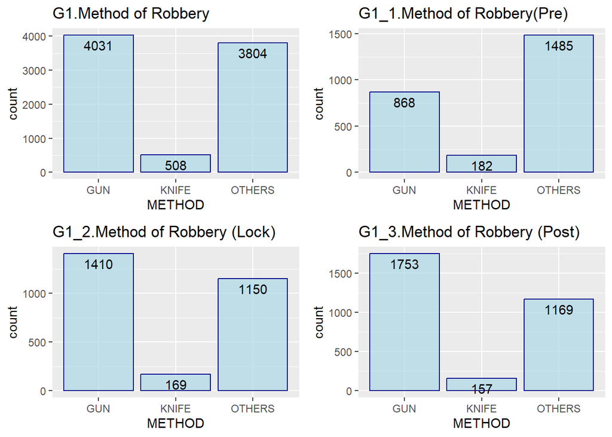

```r
# Bar plot

plot_METHOD<- ggplot(data=Robbery, aes(x=METHOD)) +
geom_bar(colour="darkblue", fill="lightblue",alpha = .7) +
geom_text(stat='count', aes(label=..count..),vjust = 1.5) + labs(x="METHOD") +
  labs(title="G1.Method of Robbery")

plot_METHOD_pre <- ggplot(data=Robbery_pre, aes(METHOD)) +
geom_bar(colour="darkblue", fill="lightblue",alpha = .7) +
geom_text(stat='count', aes(label=..count..),vjust = 1.5) +labs(x="METHOD") +
  labs(title="G1_1.Method of Robbery(Pre)")

plot_METHOD_lock <- ggplot(data=Robbery_lock, aes(METHOD)) +
geom_bar(colour="darkblue", fill="lightblue",alpha = .7) +
geom_text(stat='count', aes(label=..count..),vjust = 1.5) + labs(x="METHOD") +
  labs(title="G1_2.Method of Robbery (Lock)")

plot_METHOD_post <- ggplot(data=Robbery_post, aes(METHOD)) +
geom_bar(colour="darkblue", fill="lightblue",alpha = .7) +
geom_text(stat='count', aes(label=..count..),vjust = 1.5) + labs(x="METHOD") +
  labs(title="G1_3.Method of Robbery (Post)")

grid.arrange(plot_METHOD, plot_METHOD_pre, plot_METHOD_lock, plot_METHOD_post,
             ncol=2, nrow=2)
```

Overall, the use of guns in robberies increased from the pre-pandemic period to the lockdown period, and then continued to increase in the post-pandemic period. Additionally, the use of knives remained relatively constant throughout the three periods.

**9-1. Freq by DISTRICT :split by pandemic phrases**

These results could help law enforcement agencies to allocate their resources more effectively by focusing more on the high-risk areas (districts 5-7), especially during the pandemic times. It could also suggest that there may be underlying socio-economic factors contributing to the increase in robbery incidents in these districts during the lockdown. Overall, the data reveals some interesting patterns that could inform policymakers and law enforcement agencies to make data-driven decisions in preventing and addressing robbery incidents in different districts of the city.

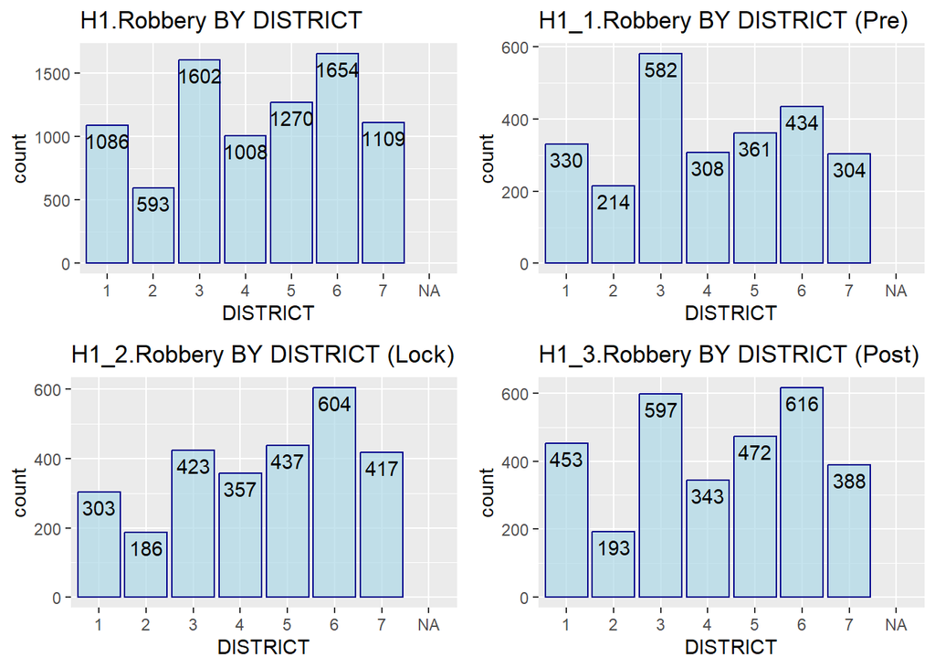

```r
# Bar plot

plot_DISTRICT<- ggplot(data=Robbery, aes(x=DISTRICT)) +
geom_bar(colour="darkblue", fill="lightblue",alpha = .7) +
geom_text(stat='count', aes(label=..count..),vjust = 1.5) + labs(x="DISTRICT") + scale_x_discrete(limits=c("1","2","3","4","5","6","7","NA")) +
  labs(title="H1.Robbery BY DISTRICT")


plot_DISTRICT_pre<- ggplot(data=Robbery_pre, aes(x=DISTRICT)) +
geom_bar(colour="darkblue", fill="lightblue",alpha = .7) +
geom_text(stat='count', aes(label=..count..),vjust = 1.5) + labs(x="DISTRICT") + scale_x_discrete(limits=c("1","2","3","4","5","6","7","NA")) +
  labs(title="H1_1.Robbery BY DISTRICT (Pre)")

plot_DISTRICT_lock<- ggplot(data=Robbery_lock, aes(x=DISTRICT)) +
geom_bar(colour="darkblue", fill="lightblue",alpha = .7) +
geom_text(stat='count', aes(label=..count..),vjust = 1.5) + labs(x="DISTRICT") + scale_x_discrete(limits=c("1","2","3","4","5","6","7","NA")) +
  labs(title="H1_2.Robbery BY DISTRICT (Lock)")

plot_DISTRICT_post<- ggplot(data=Robbery_post, aes(x=DISTRICT)) +
geom_bar(colour="darkblue", fill="lightblue",alpha = .7) +
geom_text(stat='count', aes(label=..count..),vjust = 1.5) + labs(x="DISTRICT") + scale_x_discrete(limits=c("1","2","3","4","5","6","7","NA")) +
  labs(title="H1_3.Robbery BY DISTRICT (Post)")

grid.arrange(plot_DISTRICT, plot_DISTRICT_pre, plot_DISTRICT_lock, plot_DISTRICT_post,ncol=2, nrow=2)
```

From the histograms, we can see the distribution of robbery incidents across the different districts in the city, and how they changed over time, with data available for pre-lockdown, lockdown, and post-lockdown periods.

Looking at the first histogram, we can see that District 6 had the highest number of robbery incidents overall, followed by District 3, while District 2 had the lowest number of incidents.

Overall, the histograms suggest that there were some changes in the patterns of robbery incidents across different districts over time, with some districts experiencing more dramatic changes than others.

**10-1. Boxplot distribution of PSA :split by pandemic phrases**

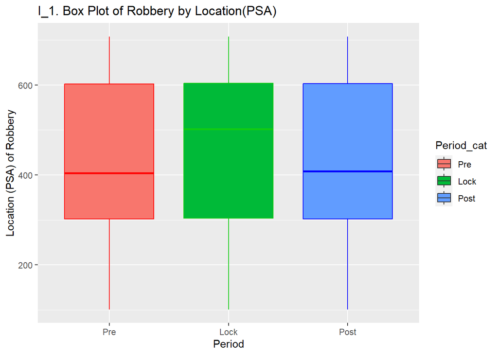

```r
boxplot_PSA <- ggplot(Robbery, aes(y=PSA, x=Period_cat, fill=Period_cat)) +
  geom_boxplot() +
  geom_boxplot( colour=c("#ff0000","#11cc11","#0000ff"), outlier.shape=8,
                outlier.colour="lightblue", outlier.size=4) +  labs(title="I_1. Box Plot of Robbery by Location(PSA)", x="Period", y = "Location (PSA) of Robbery")

boxplot_PSA
```

**10-2. Boxplot distribution of Clearance rate :split by pandemic phrases**

This section presents a boxplot distribution of clearance rate of robbery events, split by pandemic phrases. The plot shows that during the lock-down period, the number of outliers (i.e., data points that are significantly different from the rest of the data) increased, indicating a higher variance in clearance rates. Additionally, high clearance rates, which indicate that it took more time to complete the robbery event, were observed across all pandemic periods. This may imply that the robbery events during these periods were more severe or challenging, or that there were inefficiencies in police administration.

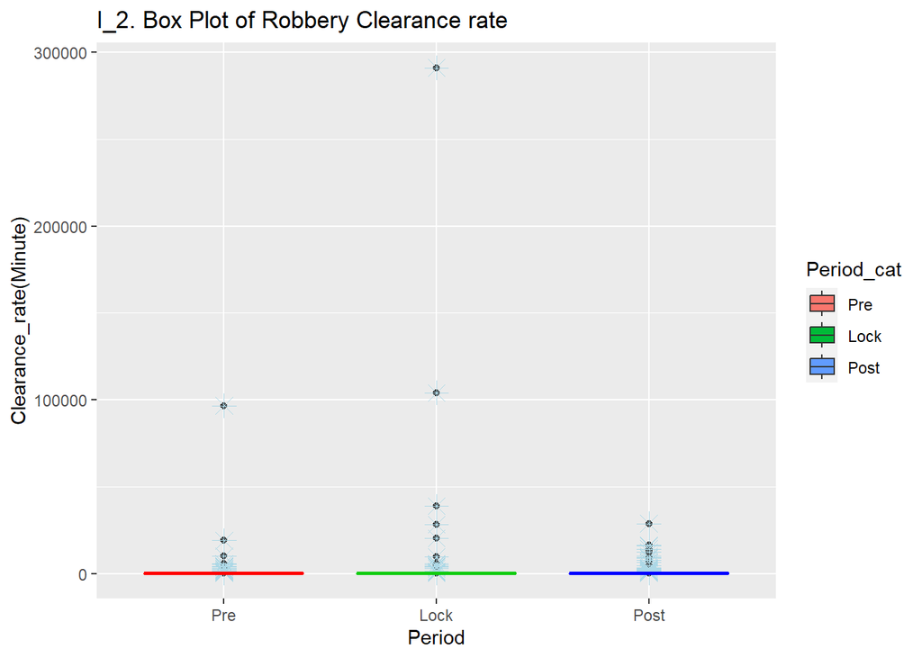

```r
boxplot_Clearance <- ggplot(Robbery, aes(y=Clearance_rate, x=Period_cat, fill=Period_cat)) +
  geom_boxplot() +
  geom_boxplot( colour=c("#ff0000","#11cc11","#0000ff"), outlier.shape=8,
                outlier.colour="lightblue", outlier.size=4) +  labs(title="I_2. Box Plot of Robbery Clearance rate", x="Period", y = "Clearance_rate(Minute)")

boxplot_Clearance
```

### 3. Unusual Observations: Data Quality

In the “Unusual Observations” section, we will provide an in-depth analysis of the data, including a quick overview of the data with and without the outliers. Outliers can significantly impact the analysis of data and can skew the results. Therefore, it is crucial to identify and examine them closely to determine their impact on the data.By examining the data with and without the outliers, we can gain a clearer picture of the trends and patterns in the data. This information will be critical in developing an accurate and reliable analysis of the impact of the COVID-19 lockdown on robbery rates in Washington D.C.

**Data Quality** To ensure data quality, we will perform the outlierKD function to detect any null values or outliers in our dataset. Once identified, we will remove them to ensure accurate analysis(Hypothesis testing). We will then display the cleaned data using a plot to visualize any trends or patterns in the data.

`OBJECTID` : there are no outliers

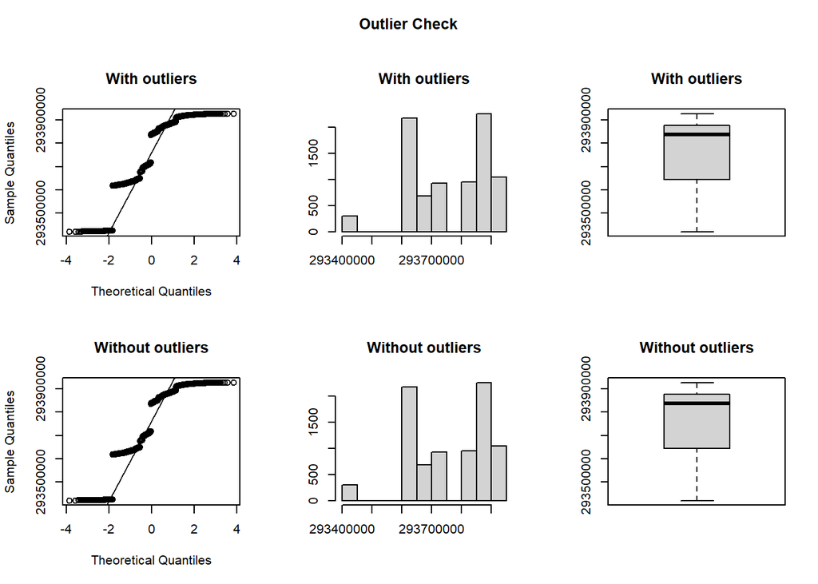

```
## Outliers identified: 0
## Propotion (%) of outliers: 0
## Mean of the outliers: NaN
## Mean without removing outliers: 293763309
## Mean if we remove outliers: 293763309
## Outliers successfully removed
```

```r
Robbery_clean = outlierKD2(Robbery, OBJECTID, rm = TRUE, boxplt = TRUE, qqplt = TRUE)
```

Continue to perform test for another continuous variables.

- Variables that have Fixed interval like `Date`, `Time_hour` don’t need test  
  So Just do that about two variables `Clearance_rate` and `PSA`

`PSA` : there are no outliers

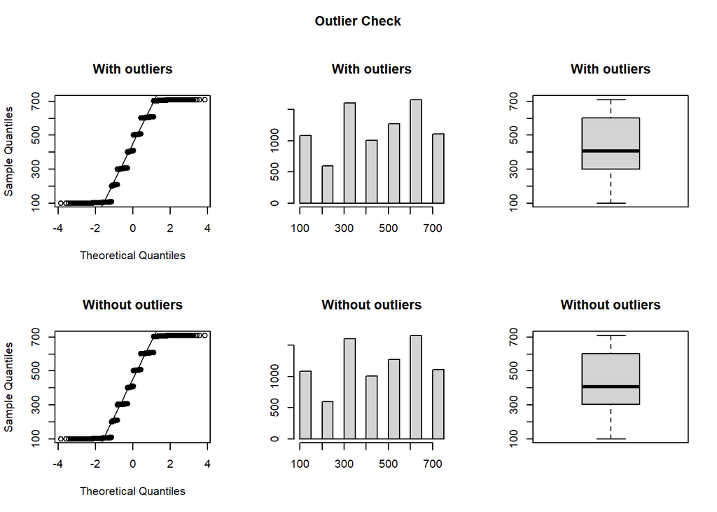

```
## Outliers identified: 0
## Propotion (%) of outliers: 0
## Mean of the outliers: NaN
## Mean without removing outliers: 427
## Mean if we remove outliers: 427
## Outliers successfully removed
```

```r
Robbery_clean = outlierKD2(Robbery, PSA, rm = TRUE, boxplt = TRUE, qqplt = TRUE)
```

The distribution of Clearance_rate is highly spread-wide, suggesting the presence of outliers. To address this, we have converted outliers with high Clearance_rate to NA, which accounts for 4.8% of the data. We will use both the original data and the outlier-excluded data to ensure a comprehensive analysis.

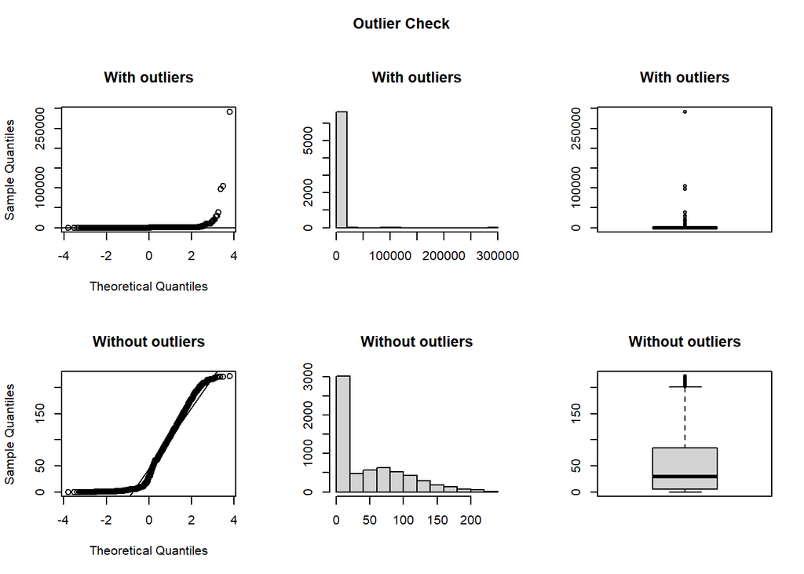

```
## Outliers identified: 304
## Propotion (%) of outliers: 4.8
## Mean of the outliers: 3656
## Mean without removing outliers: 215
## Mean if we remove outliers: 49.5
## Outliers successfully removed
```

```r
Robbery_clean = outlierKD2(Robbery, Clearance_rate, rm = TRUE, boxplt = TRUE, qqplt = TRUE)
```

```r
#str(Robbery_clean)
```

After examining the data using the outlierKD function, we have identified outliers that have been replaced with NAs. However, we have not deleted these outliers from the dataset. Instead, we have replaced them with NAs to ensure that they do not affect the analysis of the data. This approach allows us to retain the maximum amount of data while still removing any data points that may negatively impact our analysis

### Optional analysis(For subset data have high clearance_rate)

FOr example, looking through the obs that have long clearance rate (over 200 min). Interesting thing is distict 3,7. (let’s talk about that at the meeting!)

```r
#Clearance_rate

temp <- subset(Robbery,subset = Robbery$Clearance_rate > 200)
str(temp)  #361
```

```
## 'data.frame':    361 obs. of  24 variables:
##  $ OBJECTID      : int  293907739 293677670 293905240 293676902 293913211 293912189 293676534 293678539 293910014 293678164 ...
##  $ Seq           : int  20 43 72 131 155 165 177 183 206 221 ...
##  $ OFFENSE       : chr  "ROBBERY" "ROBBERY" "ROBBERY" "ROBBERY" ...
##  $ REPORT_DAT    : chr  "2019/01/04 23:24:03+00" "2019/01/10 20:32:48+00" "2019/01/15 01:19:18+00" "2019/01/25 10:53:00+00" ...
##  $ REPORT_DAT_2  : chr  "1/4/2019" "1/10/2019" "1/15/2019" "1/25/2019" ...
##  $ Period_cat    : Factor w/ 3 levels "Pre","Lock","Post": 1 1 1 1 1 1 1 1 1 1 ...
##  $ Period_cat_2  : Factor w/ 4 levels "Lock","Post",..: 3 3 3 3 3 3 3 3 3 3 ...
##  $ Year          : int  2019 2019 2019 2019 2019 2019 2019 2019 2019 2019 ...
##  $ Month         : int  1 1 1 1 1 2 2 2 2 2 ...
##  $ Month_2       : Factor w/ 48 levels "19_1","19_10",..: 1 1 1 1 1 5 5 5 5 5 ...
##  $ Month_3       : Factor w/ 48 levels "2019/01","2019/02",..: 1 1 1 1 1 2 2 2 2 2 ...
##  $ Season        : Factor w/ 4 levels "SPRING","SUMMER",..: 4 4 4 4 4 4 4 4 4 4 ...
##  $ Date          : int  4 10 15 25 30 1 3 6 10 13 ...
##  $ Date_cat      : Factor w/ 3 levels "Begin","End",..: 1 3 3 2 2 1 1 1 3 3 ...
##  $ Time_hour     : int  23 20 1 10 7 3 11 7 8 20 ...
##  $ SHIFT         : Factor w/ 3 levels "DAY","EVENING",..: 2 2 2 3 3 2 3 3 3 2 ...
##  $ Day_cat       : int  6 5 3 6 4 6 1 4 1 4 ...
##  $ Day_cat_2     : Factor w/ 2 levels "Weekday","Weekend": 1 1 1 1 1 1 2 1 2 1 ...
##  $ METHOD        : Factor w/ 3 levels "GUN","KNIFE",..: 1 3 1 1 3 1 1 3 1 3 ...
##  $ DISTRICT      : int  4 6 6 7 3 6 6 3 6 6 ...
##  $ PSA           : int  405 601 602 704 305 604 601 304 601 607 ...
##  $ START_DATE    : POSIXct, format: "2019-01-02 16:00:07" "2019-01-09 21:30:21" ...
##  $ END_DATE      : POSIXct, format: "2019-01-04 16:05:49" "2019-01-10 19:50:33" ...
##  $ Clearance_rate: int  2886 1340 370 306 2790 202 208 206 278 212 ...
```

```r
temp %>%  #Freq of Char
  count(Period_cat)
```

```
##   Period_cat   n
## 1        Pre  89
## 2       Lock  99
## 3       Post 173
```

```r
temp %>%
  count(Date_cat)
```

```
##   Date_cat   n
## 1    Begin  86
## 2      End 164
## 3   Middle 111
```

```r
temp %>%
  count(Day_cat_2)
```

```
##   Day_cat_2   n
## 1   Weekday 246
## 2   Weekend 115
```

```r
temp %>%
  count(SHIFT)
```

```
##      SHIFT   n
## 1      DAY  90
## 2  EVENING 124
## 3 MIDNIGHT 147
```

```r
temp %>%
  count(METHOD)
```

```
##   METHOD   n
## 1    GUN 199
## 2  KNIFE  17
## 3 OTHERS 145
```

```r
temp %>%
  count(DISTRICT)
```

```
##   DISTRICT  n
## 1        1 31
## 2        2 20
## 3        3 72
## 4        4 41
## 5        5 53
## 6        6 80
## 7        7 64
```

```r
#temp %>%
#  count(PSA)
```

### Final Add-on for EDA (Mar 6)

**1. [Add-on] DISTRICT**

**A. Robbery amount**

```r
prop.1 <- with(Robbery_clean, table(Period_cat, DISTRICT)) %>%
          prop.table(margin = 1)

xkabledply(prop.1*100, title = "Robbery propotion by District(%)")
```

Robbery propotion by District(%)

|  | 1 | 2 | 3 | 4 | 5 | 6 | 7 |
| --- | --- | --- | --- | --- | --- | --- | --- |
| Pre | 13.0 | 8.45 | 23.0 | 12.2 | 14.3 | 17.1 | 12.0 |
| Lock | 11.1 | 6.82 | 15.5 | 13.1 | 16.0 | 22.1 | 15.3 |
| Post | 14.8 | 6.30 | 19.5 | 11.2 | 15.4 | 20.1 | 12.7 |

```r
#contable = table(Robbery_clean$Period_cat, Robbery_clean$DISTRICT)
```

**B. Robbery quality**

```r
#make a summary table
Robbery_avg_clr <-  Robbery_clean %>% group_by(Period_cat,DISTRICT) %>%
                   summarise(avg_Clearance_rate = mean(Clearance_rate, na.rm = TRUE),.groups = 'drop')

arrange(Robbery_avg_clr, Period_cat,DISTRICT)

Robbery_avg_clr <- data.frame(Robbery_avg_clr)
```

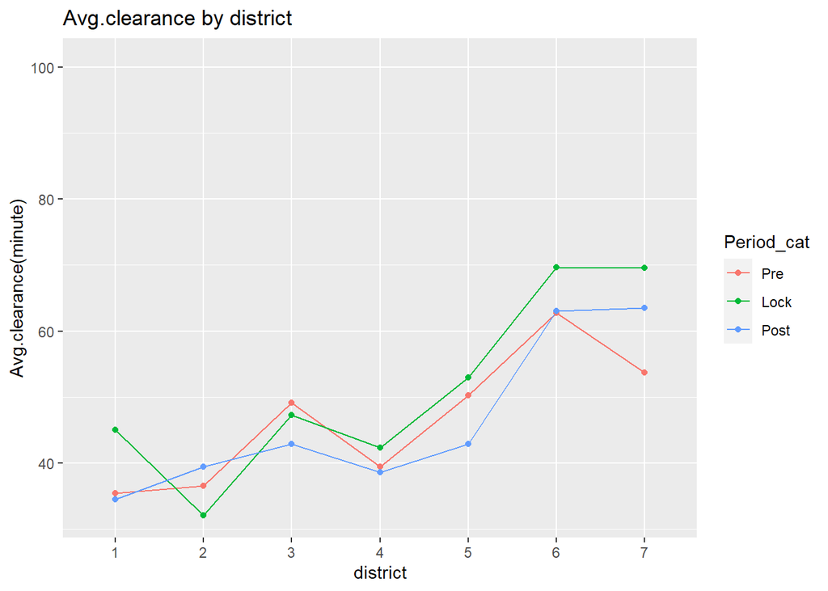

```r
plot_DISTRICT_add <- ggplot(Robbery_avg_clr, aes(DISTRICT, avg_Clearance_rate, colour = Period_cat)) + geom_line() + labs(x="district", y="Avg.clearance(minute)") +
  labs(title="Avg.clearance by district") + scale_x_discrete(limits=c("1","2","3","4","5","6","7")) + geom_point()

plot_DISTRICT_add
```

```r
#ggplot(data=Robbery_clean)+
#  geom_point(mapping = aes(x=DISTRICT, y=METHOD, color=Period_cat))+
#  ggtitle("Scatterplot of DISTRICT vs Clearance_rate for pendamic phrases")+
#  labs(x="DISTRICT", y = "Clearance_rate(minute)")
```

**2. [Add-on] METHOD**

**A. Robbery amount**

```r
prop.1 <- with(Robbery_clean, table(Period_cat, METHOD)) %>%
          prop.table(margin = 1)

xkabledply(prop.1*100, title = "Robbery propotion by METHOD(%)")
```

Robbery propotion by METHOD(%)

|  | GUN | KNIFE | OTHERS |
| --- | --- | --- | --- |
| Pre | 34.2 | 7.18 | 58.6 |
| Lock | 51.7 | 6.19 | 42.1 |
| Post | 56.9 | 5.10 | 38.0 |

**B. Robbery quality**

```r
#make a summary table
Robbery_avg_clr <-  Robbery_clean %>% group_by(METHOD,Period_cat) %>%
                   summarise(avg_Clearance_rate = mean(Clearance_rate, na.rm = TRUE),.groups = 'drop')

arrange(Robbery_avg_clr, METHOD, Period_cat)

Robbery_avg_clr <- data.frame(Robbery_avg_clr)
```

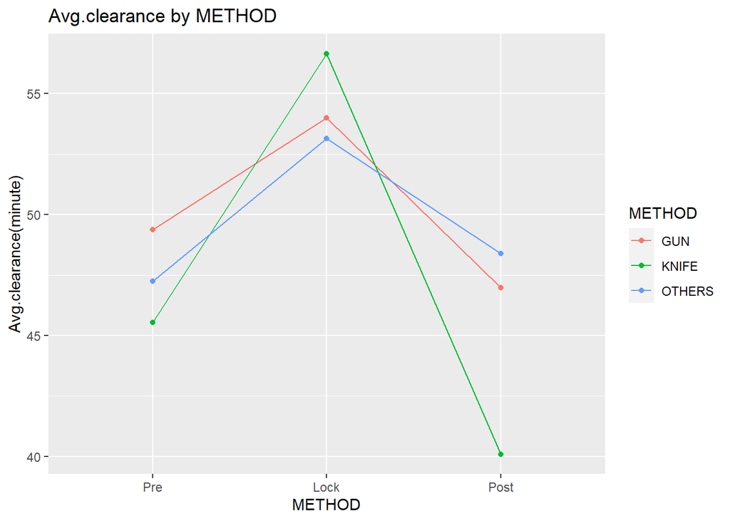

```r
plot_METHOD_add <- ggplot(Robbery_avg_clr, aes(Period_cat, avg_Clearance_rate, group = METHOD, ,colour = METHOD)) + geom_line() + labs(x="METHOD", y="Avg.clearance(minute)") + geom_point() + labs(title="Avg.clearance by METHOD")

plot_METHOD_add
```

**3. [Add-on] shift**

**A. Robbery amount**

```r
prop.1 <- with(Robbery_clean, table(Period_cat, SHIFT)) %>%
          prop.table(margin = 1)

xkabledply(prop.1*100, title = "Robbery propotion by SHIFT(%)")
```

Robbery propotion by SHIFT(%)

|  | DAY | EVENING | MIDNIGHT |
| --- | --- | --- | --- |
| Pre | 18.4 | 40.4 | 41.2 |
| Lock | 19.9 | 38.6 | 41.5 |
| Post | 21.1 | 39.8 | 39.1 |

**C. Robbery quality**

```r
#make a summary table
Robbery_avg_clr <-  Robbery_clean %>% group_by(SHIFT,Period_cat) %>%
                   summarise(avg_Clearance_rate = mean(Clearance_rate, na.rm = TRUE),.groups = 'drop')

arrange(Robbery_avg_clr, SHIFT, Period_cat)

Robbery_avg_clr <- data.frame(Robbery_avg_clr)
```

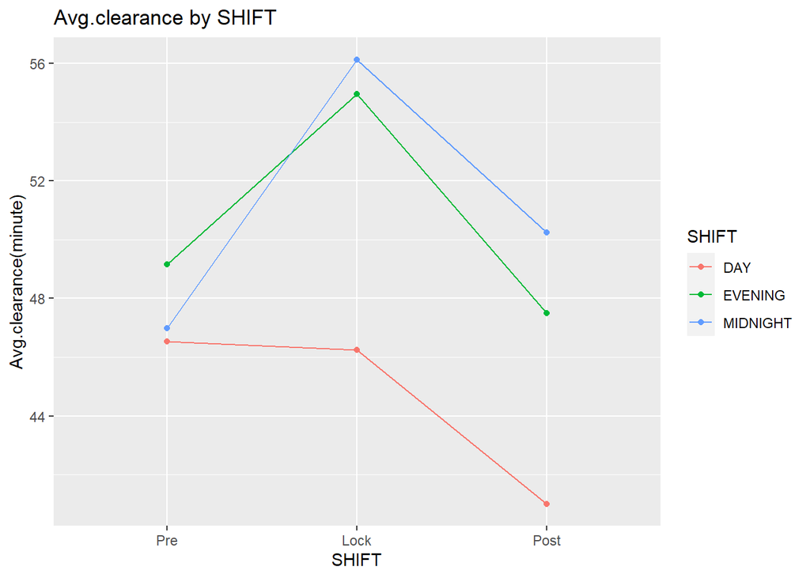

```r
plot_SHIFT_add <- ggplot(Robbery_avg_clr, aes(Period_cat, avg_Clearance_rate, group = SHIFT, ,colour = SHIFT)) + geom_line() + labs(x="SHIFT", y="Avg.clearance(minute)") + geom_point() + labs(title="Avg.clearance by SHIFT")

plot_SHIFT_add
```

#####################3

## (Temporary) Organize Datasets before moving on to the Hypothesis test

### Wrap-up final datasets Save (Begin next step by loading these data)

1. Main datasets: 5 (2 total, 3 subsets)
- original: Robbery, pre, lock, post
- outlier excluded data: Robbery_clean
2. Summary datasets: 5
- (Sum of frequency, origin from Robbery_clean) Robbery_date_sum, Robbery_month_sum, Robbery_Date_cat_sum
- (Average of clearance_rate) Robbery_district_avg_clr (origin from both Robbery), Robbery_clean_district_avg_clr (origin from Robbery_clean)

```r
# This block will run/execute but just skip showing result

temp <- select(Robbery_clean,REPORT_DAT_2,Period_cat)

Robbery_date_sum <- count(temp,REPORT_DAT_2,Period_cat, sort=FALSE)
#str(Robbery_date_sum)
arrange(Robbery_date_sum, REPORT_DAT_2)  #Ascending
#head(Robbery_date_sum,5)
```

*The first 4 rows of the first summary dataset (Robbery_date_sum) are:*

```r
xkabledply(Robbery_date_sum[1:4,], title = "First Four Rows of Dataframe: `Robbery_date_sum`")
```

First Four Rows of Dataframe: `Robbery_date_sum`

| REPORT_DAT_2 | Period_cat | n |
| --- | --- | --- |
| 1/1/2019 | Pre | 5 |
| 1/1/2020 | Pre | 7 |
| 1/1/2021 | Lock | 4 |
| 1/1/2022 | Post | 15 |

```r
temp <- select(Robbery_clean,Month_3,Period_cat)

Robbery_month_sum <- count(temp,Month_3,Period_cat, sort=FALSE)
#str(Robbery_date_sum)
arrange(Robbery_month_sum, Month_3)  #Ascending
#head(Robbery_date_sum,10)
```

*The first 4 rows of the second summary dataset (Robbery_month_sum) are:*

```r
xkabledply(Robbery_month_sum[1:4,], title = "First Four Rows of Dataframe: `Robbery_month_sum`")
```

First Four Rows of Dataframe: `Robbery_month_sum`

| Month_3 | Period_cat | n |
| --- | --- | --- |
| 2019/01 | Pre | 164 |
| 2019/02 | Pre | 126 |
| 2019/03 | Pre | 142 |
| 2019/04 | Pre | 141 |

```r
temp <- select(Robbery_clean,Date_cat,Period_cat)

Robbery_Date_cat_sum <- count(temp,Date_cat,Period_cat, sort=FALSE)
#str(Robbery_date_sum)
arrange(Robbery_Date_cat_sum, Date_cat,Period_cat)  #Ascending
#head(Robbery_date_sum,10)
```

*The third summary dataset (Robbery_Date_cat_sum) are:*

```r
xkabledply(Robbery_Date_cat_sum, title = "Dataframe: `Robbery_Date_cat_sum`")
```

Dataframe: `Robbery_Date_cat_sum`

| Date_cat | Period_cat | n |
| --- | --- | --- |
| Begin | Pre | 705 |
| Begin | Lock | 760 |
| Begin | Post | 879 |
| End | Pre | 988 |
| End | Lock | 1034 |
| End | Post | 1173 |
| Middle | Pre | 842 |
| Middle | Lock | 935 |
| Middle | Post | 1027 |

```r
Robbery_district_avg_clr <-  Robbery %>% group_by(Period_cat, DISTRICT) %>%
                   summarise(avg_Clearance_rate = mean(Clearance_rate, na.rm = TRUE),.groups = 'drop')

arrange(Robbery_district_avg_clr, Period_cat,DISTRICT)

Robbery_district_avg_clr <- data.frame(Robbery_district_avg_clr)
```

*The first 4 rows of the fourth summary dataset (Robbery_district_avg_clr) are:* + Robbery_district_avg_clr: origin for **Robbery**

```r
xkabledply(Robbery_district_avg_clr[1:4,], title = "Dataframe: `Robbery_district_avg_clr`")
```

Dataframe: `Robbery_district_avg_clr`

| Period_cat | DISTRICT | avg_Clearance_rate |
| --- | --- | --- |
| Pre | 1 | 58.4 |
| Pre | 2 | 40.4 |
| Pre | 3 | 123.7 |
| Pre | 4 | 70.5 |

```r
Robbery_clean_district_avg_clr <-  Robbery_clean %>% group_by(Period_cat, DISTRICT) %>%
                   summarise(avg_Clearance_rate = mean(Clearance_rate, na.rm = TRUE),.groups = 'drop')

arrange(Robbery_clean_district_avg_clr, Period_cat,DISTRICT)

Robbery_clean_district_avg_clr <- data.frame(Robbery_clean_district_avg_clr)
```

*The first 4 rows of the fifth summary dataset (Robbery_clean_district_avg_clr) are:* + Robbery_clean_district_avg_clr: origin for **Robbery_clean (outlier excluded)**

```r
xkabledply(Robbery_clean_district_avg_clr[1:4,], title = "Dataframe: `Robbery_district_avg_clr`")
```

Dataframe: `Robbery_district_avg_clr`

| Period_cat | DISTRICT | avg_Clearance_rate |
| --- | --- | --- |
| Pre | 1 | 35.4 |
| Pre | 2 | 36.5 |
| Pre | 3 | 49.1 |
| Pre | 4 | 39.5 |

**1. Save the 5 Main current datasets(Mar 3)/ and Load**

```r
#Save current data
#readr::write_rds(Robbery, "Robbery_230303.Rds")
#readr::write_rds(Robbery_pre, "Robbery_pre_230303.Rds")
#readr::write_rds(Robbery_lock, "Robbery_lock_230303.Rds")
#readr::write_rds(Robbery_post, "Robbery_post_230303.Rds")
#readr::write_rds(Robbery_clean, "Robbery_clean_230303.Rds")

#Use this code to load
#Robbery <-
#  readr::read_rds("Robbery_230303.Rds")

#Robbery_clean <-
#  readr::read_rds("Robbery_clean_230303.Rds")

#Load subset
#Robbery_pre <-
#  readr::read_rds("Robbery_pre_230303.Rds")

#Robbery_lock <-
#  readr::read_rds("Robbery_lock_230303.Rds")

#Robbery_post <-
#  readr::read_rds("Robbery_post_230303.Rds")
```

Verify again before moving on the next step

```r
#str(Robbery)
#str(Robbery_pre)
#str(Robbery_lock)
#str(Robbery_post)
#str(Robbery_clean)
#head(Robbery,10)
```

**2.Save the 5 Summary datasets(Mar 3)/ and Load**

```r
#Save current data
#readr::write_rds(Robbery_date_sum, "Robbery_date_sum_230303.Rds")
#readr::write_rds(Robbery_month_sum, "Robbery_month_sum_230303.Rds")
#readr::write_rds(Robbery_Date_cat_sum, "Robbery_Date_cat_sum_230303.Rds")
#readr::write_rds(Robbery_district_avg_clr, "Robbery_district_avg_clr_230303.Rds")
#readr::write_rds(Robbery_clean_district_avg_clr, "Robbery_clean_district_avg_clr_230303.Rds")

#Use this code to load
#Robbery_date_sum <-
#  readr::read_rds("Robbery_date_sum_230303.Rds")

#Robbery_month_sum <-
#  readr::read_rds("Robbery_month_sum_230303.Rds")

#Robbery_Date_cat_sum <-
#  readr::read_rds("Robbery_Date_cat_sum_230303.Rds")

#Robbery_district_avg_clr <-
#  readr::read_rds("Robbery_district_avg_clr_230303.Rds")

#Robbery_clean_district_avg_clr <-
#  readr::read_rds("Robbery_clean_district_avg_clr_230303.Rds")
```

Verify again before moving on the next step

```r
#str(Robbery_date_sum)
#str(Robbery_month_sum)
#str(Robbery_Date_cat_sum)
#str(Robbery_district_avg_clr)
#str(Robbery_clean_district_avg_clr)
```

### (Mar 4) Creating variable for hypothesis test (ANd save again)

- Period_cat(pre,lock,post) > Period_cat_num(1,2,3)
- 5 Main table: Robbery Robbery_clean Robbery_pre Robbery_lock Robbery_post
- 5 Summary table
- Robbery_date_sum, Robbery_month_sum, Robbery_Date_cat_sum
- Robbery_district_avg_clr (origin from both Robbery), Robbery_clean_district_avg_clr (origin from Robbery_clean)

I applied below logic for our 10 tables and finished verifying them. So, I will just omit codes of them

```r
#attach(Robbery)
#Robbery$Period_cat_num[Period_cat == 'Pre'] <- 1
#Robbery$Period_cat_num[Period_cat == 'Lock'] <- 2
#Robbery$Period_cat_num[Period_cat  == 'Post'] <- 3
#detach(Robbery)

#count(Robbery,Period_cat_num)
# correct: pre 2535, lock 2729, post3079
```

**(Mar 4) I Saved updated tables(overwrite).**

```r
#Save current data
#readr::write_rds(Robbery, "Robbery_230303.Rds")
#readr::write_rds(Robbery_pre, "Robbery_pre_230303.Rds")
#readr::write_rds(Robbery_lock, "Robbery_lock_230303.Rds")
#readr::write_rds(Robbery_post, "Robbery_post_230303.Rds")
#readr::write_rds(Robbery_clean, "Robbery_clean_230303.Rds")

#Use this code to load
Robbery <-
  readr::read_rds("Robbery_230303.Rds")

Robbery_clean <-
  readr::read_rds("Robbery_clean_230303.Rds")

#Load subset
Robbery_pre <-
  readr::read_rds("Robbery_pre_230303.Rds")

Robbery_lock <-
  readr::read_rds("Robbery_lock_230303.Rds")

Robbery_post <-
  readr::read_rds("Robbery_post_230303.Rds")
```

Verify again before moving on the next step

```r
#str(Robbery)
#str(Robbery_pre)
#str(Robbery_lock)
#str(Robbery_post)
#str(Robbery_clean)
#head(Robbery,10)
```

**# Save the 5 Summary datasets(Mar 4)/ and Load**

```r
#Save current data
#readr::write_rds(Robbery_date_sum, "Robbery_date_sum_230303.Rds")
#readr::write_rds(Robbery_month_sum, "Robbery_month_sum_230303.Rds")
#readr::write_rds(Robbery_Date_cat_sum, "Robbery_Date_cat_sum_230303.Rds")
#readr::write_rds(Robbery_district_avg_clr, "Robbery_district_avg_clr_230303.Rds")
#readr::write_rds(Robbery_clean_district_avg_clr, "Robbery_clean_district_avg_clr_230303.Rds")

#Use this code to load
Robbery_date_sum <-
  readr::read_rds("Robbery_date_sum_230303.Rds")

Robbery_month_sum <-
  readr::read_rds("Robbery_month_sum_230303.Rds")

Robbery_Date_cat_sum <-
  readr::read_rds("Robbery_Date_cat_sum_230303.Rds")

Robbery_district_avg_clr <-
  readr::read_rds("Robbery_district_avg_clr_230303.Rds")

Robbery_clean_district_avg_clr <-
  readr::read_rds("Robbery_clean_district_avg_clr_230303.Rds")
```

Verify again before moving on the next step

```r
#str(Robbery_date_sum)
#str(Robbery_month_sum)
#str(Robbery_Date_cat_sum)
#str(Robbery_district_avg_clr)
#str(Robbery_clean_district_avg_clr)
```

## Hypothesis test 1- Anova test

Hypothesis test aims to Find a statistical evidence if there is significant difference between three phases, in terms of **robbery pattern of pre-pandemic, lock-down, and post-pandemic.** )

- ANOVA: compare means among different groups
- Chi square: compare frequencies and proportions among different groups

By specifying robbery pattern, We set up 5 tests as belows. level of significance standard $\alpha$ = 0.05 (The 95% confidence level

### 1. Daily robbery frequency (Quantitative var)

**(A) Anova test**

- Null hypothesis: $H_0:$ The Washington DC has same mean of daily robbery frequency in `pre-pandemic`,`lock-down`, and `post-pandemic` phases.
- Alternative hypothesis: $H_1:$ The mean daily robbery frequency of three phases are NOT all the same

```r
str(Robbery_date_sum)
count(Robbery_date_sum,Period_cat_num)
```

```r
anova_dayily_rob = aov(n~Period_cat, data = Robbery_date_sum)

anova_summary = summary(anova_dayily_rob)
#anova_summary
xkabledply(anova_dayily_rob)
```

Model: n ~ Period_cat

|  | Df | Sum Sq | Mean Sq | F value | Pr(>F) |
| --- | --- | --- | --- | --- | --- |
| Period_cat | 2 | 132 | 66.1 | 7.19 | 0.0008 |
| Residuals | 1437 | 13215 | 9.2 | NA | NA |

```r
#FYI. we can use Period_cat_num after Transforming as factor for analysis
#Robbery_date_sum$Period_cat_num<- as.factor(Robbery_date_sum$Period_cat_num)

#anova_dayily_rob = aov(n~Period_cat_num, data = Robbery_date_sum)
#anova_summary = summary(anova_dayily_rob)
#anova_summary
```

- F value of the test is **7.19.**
- The p-value is **0.001**, which is < $\alpha$ (0.05), right-tailed for one-way ANOVA.
- **The data present is enough evidence to reject $H_0$ at the set significance level.**

**(B) Post-hoc Tukey HSD**

- we use tukeyHSD to pursue to find out which pairs (of phases) are different.

```r
tukey_anova_dayily_rob <- TukeyHSD(anova_dayily_rob)
tukey_anova_dayily_rob
```

```
##   Tukey multiple comparisons of means
##     95% family-wise confidence level
##
## Fit: aov(formula = n ~ Period_cat, data = Robbery_date_sum)
##
## $Period_cat
##               diff    lwr   upr p adj
## Lock-Pre  -0.63873 -1.108 -0.17 0.004
## Post-Pre  -0.00771 -0.476  0.46 0.999
## Post-Lock  0.63103  0.185  1.08 0.003
```

```r
#xkabledply(tukey_anova_dayily_rob)
```

- `pre-pandemic`and`lock-down` are pairwise considered having different means.
- Also, `post-pandemic` and`lock-down` are pairwise considered having different means.
- On the other hand, `pre-pandemic`and`post-pandemic` are not significant at 0.05 level.

**(C) Exclude outlier**

- We thought that outliers would affect the result, so decided to test again after excluding outliers. 5.5% of entire data was converted to NA.

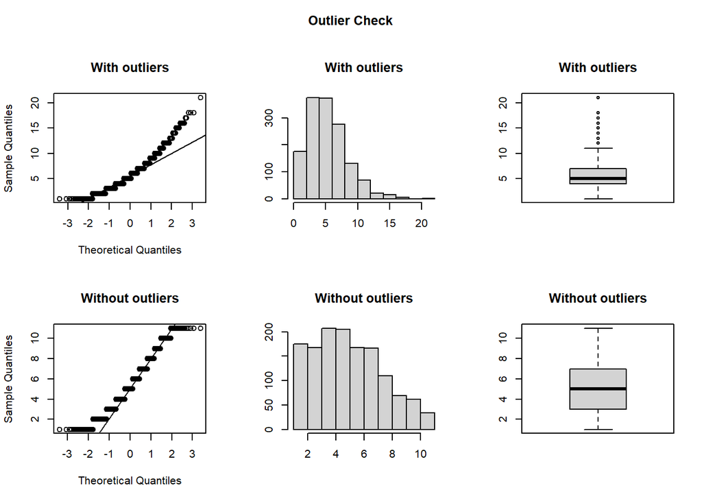

```
## Outliers identified: 75
## Propotion (%) of outliers: 5.5
## Mean of the outliers: 13.5
## Mean without removing outliers: 5.79
## Mean if we remove outliers: 5.37
## Outliers successfully removed
```

```r
Robbery_date_sum_exc = outlierKD2(Robbery_date_sum, n, rm = TRUE, boxplt = TRUE, qqplt = TRUE)
```

```r
anova_dayily_rob_exc = aov(n~Period_cat, data = Robbery_date_sum_exc)

anova_summary_exc = summary(anova_dayily_rob_exc)
#anova_summary_exc
xkabledply(anova_summary_exc)
```

Table

|  | Df | Sum Sq | Mean Sq | F value | Pr(>F) |
| --- | --- | --- | --- | --- | --- |
| Period_cat | 2 | 86 | 43.02 | 7.11 | 0.0008 |
| Residuals | 1362 | 8244 | 6.05 | NA | NA |

```r
tukey_anova_dayily_rob_exc <- TukeyHSD(anova_dayily_rob_exc)
tukey_anova_dayily_rob_exc
```

```
##   Tukey multiple comparisons of means
##     95% family-wise confidence level
##
## Fit: aov(formula = n ~ Period_cat, data = Robbery_date_sum_exc)
##
## $Period_cat
##             diff      lwr    upr p adj
## Lock-Pre  -0.614 -1.00244 -0.225 0.001
## Post-Pre  -0.237 -0.62859  0.154 0.330
## Post-Lock  0.376  0.00456  0.748 0.046
```

```r
#xkabledply(tukey_anova_dayily_rob_exc)
```

- The test result is same as the previous test(including outliers)

### 2. Monthly robbery frequency (Quantitative var)

**(A) Anova test**

- Null hypothesis: $H_0:$ The Washington DC has same mean of monthly robbery frequency in `pre-pandemic`,`lock-down`, and `post-pandemic` phases.
- Alternative hypothesis: $H_1:$ The mean monthly robbery frequency of three phases are NOT all the same

```r
str(Robbery_month_sum)
count(Robbery_month_sum,Period_cat)
```

```r
anova_monthly_rob = aov(n~Period_cat, data = Robbery_month_sum)
anova_summary = summary(anova_monthly_rob)
#anova_summary
xkabledply(anova_dayily_rob)
```

Model: n ~ Period_cat

|  | Df | Sum Sq | Mean Sq | F value | Pr(>F) |
| --- | --- | --- | --- | --- | --- |
| Period_cat | 2 | 132 | 66.1 | 7.19 | 0.0008 |
| Residuals | 1437 | 13215 | 9.2 | NA | NA |

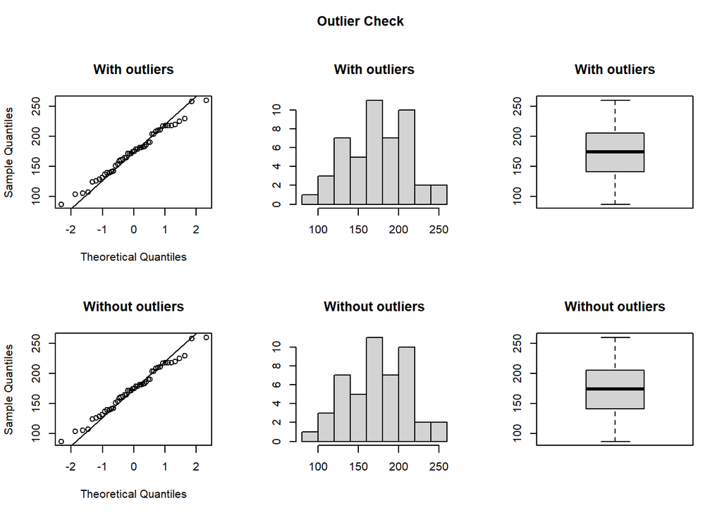

```r
temp = outlierKD2(Robbery_month_sum, n, rm = TRUE, boxplt = TRUE, qqplt = TRUE)
```

```r
temp = aov(n~Period_cat, data = temp)
temp = summary(temp)
temp
```

[output not shown]

### 3. Daily robbery average time hour (Quantitative var)

- Outliers of `Clearance_rate` has been excluded.

**(A) Anova test**

```r
#make a summary table
Robbery_avg_time <-  Robbery_clean %>% group_by(Period_cat, REPORT_DAT_2) %>%
                   summarise(avg_Time_hour = mean(Time_hour, na.rm = TRUE),.groups = 'drop')

arrange(Robbery_avg_time, Period_cat,REPORT_DAT_2)

Robbery_avg_time <- data.frame(Robbery_avg_time)
```

```r
anova_daily_rob = aov(avg_Time_hour~Period_cat, data = Robbery_avg_time)
anova_summary = summary(anova_daily_rob)
anova_summary
```

```
##               Df Sum Sq Mean Sq F value Pr(>F)
## Period_cat     2     40    20.1     1.3   0.27
## Residuals   1437  22221    15.5
```

```r
#xkabledply(anova_daily_rob)
```

- **We fail to reject the null hypothesis $H_0$ at the set significance level.**

### 4. Daily robbery average time of clr (Quantitative var)

- Outliers of `Clearance_rate` has been excluded.

**(A) Anova test**

```r
#make a summary table
Robbery_avg_clr <-  Robbery_clean %>% group_by(Period_cat, REPORT_DAT_2) %>%
                   summarise(avg_Clearance_rate = mean(Clearance_rate, na.rm = TRUE),.groups = 'drop')

arrange(Robbery_avg_clr, Period_cat,REPORT_DAT_2)

Robbery_avg_clr <- data.frame(Robbery_avg_clr)
```

```r
anova_daily_rob = aov(avg_Clearance_rate~Period_cat, data = Robbery_avg_clr)

anova_summary = summary(anova_daily_rob)
anova_summary
```

```
##               Df  Sum Sq Mean Sq F value  Pr(>F)
## Period_cat     2   12876    6438    7.34 0.00067 ***
## Residuals   1410 1236278     877
## ---
## Signif. codes:  0 '***' 0.001 '**' 0.01 '*' 0.05 '.' 0.1 ' ' 1
## 결측으로 인하여 27개의 관측치가 삭제되었습니다.
```

```r
#xkabledply(anova_daily_rob)
```

- F value of the test is **7.34.**
- The p-value is **0.001**, which is < $\alpha$ (0.05), right-tailed for one-way ANOVA.
- **So, The data present is enough evidence to reject $H_0$ at the set significance level.**

**(B) Post-hoc Tukey HSD**

- we use tukeyHSD to pursue to find out which pairs (of phases) are different.

```r
tukey_anova_dayily_rob <- TukeyHSD(anova_daily_rob)
tukey_anova_dayily_rob
```

```
##   Tukey multiple comparisons of means
##     95% family-wise confidence level
##
## Fit: aov(formula = avg_Clearance_rate ~ Period_cat, data = Robbery_avg_clr)
##
## $Period_cat
##            diff     lwr   upr p adj
## Lock-Pre   5.03   0.392  9.66 0.030
## Post-Pre  -1.97  -6.576  2.63 0.574
## Post-Lock -7.00 -11.391 -2.60 0.001
```

```r
#xkabledply(tukey_anova_dayily_rob)
```

- `pre-pandemic`and`lock-down` are pairwise considered having different means.
- Also, `post-pandemic` and`lock-down` are pairwise considered having different means.
- On the other hand, `pre-pandemic`and`post-pandemic` are not significant at 0.05 level.

## Hypothesis test 2- Chi square test(GOF)

- Even though frequency of robbery would not same by pandemic phrases, the pattern of incident would be same or not.
- So we conducted Chi square test to compare proportions of a few categorical values among three phrase groups.
- Basically, we guess the `pre-pandemic` is the expected frequencies, and conducted test to the `lock-down`, and `post-pandemic` phases.

### 1.Robbery incident pattern by date (Categorical var)**

- Null hypothesis: $H_0:$ The robbery distribution of `pre-pandemic` phase by the beginning, middle, and end of the month matches `lock-down`phases.
- Alternative hypothesis: $H_1:$ They do not match

```r
temp <- count(Robbery_lock,Date_cat)
value = c(Begin=temp[1,2], End=temp[2,2], Middle=temp[3,2])

temp <- count(Robbery_pre,Date_cat)
exp_freq = c(temp[1,2]/2535, temp[2,2]/2535,temp[3,2]/2535)

# Next perform chi-square test
chigoodness = chisq.test(value, p = exp_freq) # p stands for proportions
# look at the result
chigoodness
```

```
##
##  Chi-squared test for given probabilities
##
## data:  value
## X-squared = 2, df = 2, p-value = 0.4
```

```r
xkabledply( as.table(chigoodness$expected), title = "Expected frequencies", wide = T)
```

Expected frequencies

| Begin | End | Middle |
| --- | --- | --- |
| 759 | 1064 | 906 |

$\chi^2$ value of the test is 1.726, and p-value is 0.422.

- **So we fail to reject the null hypothesis $H_0$ at the set significance level.**
- At the test of comparing `pre-pandemic` and `post-pandemic`phase, the result is same.(fail to reject $H_0$)

```r
temp <- count(Robbery_post,Date_cat)
value = c(Begin=temp[1,2], End=temp[2,2], Middle=temp[3,2])

temp <- count(Robbery_pre,Date_cat)
exp_freq = c(temp[1,2]/2535, temp[2,2]/2535,temp[3,2]/2535)

# Next perform chi-square test
chigoodness = chisq.test(value, p = exp_freq) # p stands for proportions
# look at the result
chigoodness
```

```
##
##  Chi-squared test for given probabilities
##
## data:  value
## X-squared = 1, df = 2, p-value = 0.5
```

### 2.Robbery incident pattern by timezone (Categorical var)**

- **[Lock vs Pre]**

```r
temp <- count(Robbery_lock,SHIFT)
value = c(DAY=temp[1,2], EVENING=temp[2,2], MIDNIGHT=temp[3,2])

temp <- count(Robbery_pre,SHIFT)
exp_freq = c(temp[1,2]/2535, temp[2,2]/2535,temp[3,2]/2535)

# Next perform chi-square test
chigoodness = chisq.test(value, p = exp_freq) # p stands for proportions
# look at the result
chigoodness
```

```
##
##  Chi-squared test for given probabilities
##
## data:  value
## X-squared = 6, df = 2, p-value = 0.06
```

- **[Post vs Pre] The data present is enough evidence to reject $H_0$ at the set significance level.**

```r
temp <- count(Robbery_post,SHIFT)
value = c(DAY=temp[1,2], EVENING=temp[2,2], MIDNIGHT=temp[3,2])

temp <- count(Robbery_pre,SHIFT)
exp_freq = c(temp[1,2]/2535, temp[2,2]/2535,temp[3,2]/2535)

# Next perform chi-square test
chigoodness = chisq.test(value, p = exp_freq) # p stands for proportions
# look at the result
chigoodness
```

```
##
##  Chi-squared test for given probabilities
##
## data:  value
## X-squared = 16, df = 2, p-value = 0.0004
```

### 3.Robbery incident pattern by robbery methods (Categorical var)**

- **[Lock vs Pre] The data present is enough evidence to reject $H_0$ at the set significance level.**

```r
temp <- count(Robbery_lock,METHOD)
value = c(GUN=temp[1,2], KNIFE=temp[2,2], OTHERS=temp[3,2])

temp <- count(Robbery_pre,METHOD)
exp_freq = c(temp[1,2]/2535, temp[2,2]/2535,temp[3,2]/2535)

# Next perform chi-square test
chigoodness = chisq.test(value, p = exp_freq) # p stands for proportions
# look at the result
chigoodness
```

```
##
##  Chi-squared test for given probabilities
##
## data:  value
## X-squared = 372, df = 2, p-value <0.0000000000000002
```

- **[Post vs Pre] The data present is enough evidence to reject $H_0$ at the set significance level.**

```r
temp <- count(Robbery_post,METHOD)
value = c(GUN=temp[1,2], KNIFE=temp[2,2], OTHERS=temp[3,2])

temp <- count(Robbery_pre,METHOD)
exp_freq = c(temp[1,2]/2535, temp[2,2]/2535,temp[3,2]/2535)

# Next perform chi-square test
chigoodness = chisq.test(value, p = exp_freq) # p stands for proportions
# look at the result
chigoodness
```

```
##
##  Chi-squared test for given probabilities
##
## data:  value
## X-squared = 705, df = 2, p-value <0.0000000000000002
```

- **[Post vs Lock] The data present is enough evidence to reject $H_0$ at the set significance level.**

```r
temp <- count(Robbery_post,METHOD)
value = c(GUN=temp[1,2], KNIFE=temp[2,2], OTHERS=temp[3,2])

temp <- count(Robbery_lock,METHOD)
exp_freq = c(temp[1,2]/2729, temp[2,2]/2729,temp[3,2]/2729)

# Next perform chi-square test
chigoodness = chisq.test(value, p = exp_freq) # p stands for proportions
# look at the result
chigoodness
```

```
##
##  Chi-squared test for given probabilities
##
## data:  value
## X-squared = 35, df = 2, p-value = 0.00000002
```

### 4.Robbery incident pattern by robbery districts (Categorical var)**

- **[Lock vs Pre] The data present is enough evidence to reject $H_0$ at the set significance level.**

```r
#A~G: dist 1~7, h:NA)
temp <- count(Robbery_lock,DISTRICT)
value = c(a=temp[1,2], b=temp[2,2], c=temp[3,2],d=temp[4,2], e=temp[5,2], f=temp[6,2],g=temp[7,2],h=temp[8,2])

temp <- count(Robbery_pre,DISTRICT)
exp_freq = c(temp[1,2]/2535,temp[2,2]/2535,temp[3,2]/2535,temp[4,2]/2535,temp[5,2]/2535,temp[6,2]/2535,temp[7,2]/2535,temp[8,2]/2535)

# Next perform chi-square test
chigoodness = chisq.test(value, p = exp_freq) # p stands for proportions
# look at the result
chigoodness
```

```
##
##  Chi-squared test for given probabilities
##
## data:  value
## X-squared = 155, df = 7, p-value <0.0000000000000002
```

- **[Post vs Pre] The data present is enough evidence to reject $H_0$ at the set significance level.**

```r
#A~G: dist 1~7, h:NA)
temp <- count(Robbery_post,DISTRICT)
value = c(a=temp[1,2], b=temp[2,2], c=temp[3,2],d=temp[4,2], e=temp[5,2], f=temp[6,2],g=temp[7,2],h=temp[8,2])

temp <- count(Robbery_pre,DISTRICT)
exp_freq = c(temp[1,2]/2535,temp[2,2]/2535,temp[3,2]/2535,temp[4,2]/2535,temp[5,2]/2535,temp[6,2]/2535,temp[7,2]/2535,temp[8,2]/2535)

# Next perform chi-square test
chigoodness = chisq.test(value, p = exp_freq) # p stands for proportions
# look at the result
chigoodness
```

```
##
##  Chi-squared test for given probabilities
##
## data:  value
## X-squared = 150, df = 7, p-value <0.0000000000000002
```

- **[Post vs Lock] The data present is enough evidence to reject $H_0$ at the set significance level.**

```r
#A~G: dist 1~7, h:NA)
temp <- count(Robbery_post,DISTRICT)
value = c(a=temp[1,2], b=temp[2,2], c=temp[3,2],d=temp[4,2], e=temp[5,2], f=temp[6,2],g=temp[7,2],h=temp[8,2])

temp <- count(Robbery_lock,DISTRICT)
exp_freq = c(temp[1,2]/2729,temp[2,2]/2729,temp[3,2]/2729,temp[4,2]/2729,
             temp[5,2]/2729,temp[6,2]/2729,temp[7,2]/2729,temp[8,2]/2729)

# Next perform chi-square test
chigoodness = chisq.test(value, p = exp_freq) # p stands for proportions
# look at the result
chigoodness
```

```
##
##  Chi-squared test for given probabilities
##
## data:  value
## X-squared = 194, df = 7, p-value <0.0000000000000002
```

**Chi-squared Test (the draft, ignore ignore ignore, need more work with this !!!!!!!!!!!!!!!!!**

```r
table2 = table(Robbery$Period_cat, Robbery$Season)
xkabledply(table2, title="Contingency table 2'")
```

Contingency table 2’

|  | SPRING | SUMMER | AUTUMN | WINTER |
| --- | --- | --- | --- | --- |
| Pre | 469 | 645 | 649 | 772 |
| Lock | 664 | 919 | 665 | 481 |
| Post | 452 | 672 | 1135 | 820 |

```r
chitest2 = chisq.test(table2)
chitest2
```

```
##
##  Pearson's Chi-squared test
##
## data:  table2
## X-squared = 337, df = 6, p-value <0.0000000000000002
```

The p-value is significantly less than 0.05, so we can reject the null hypothesis (the season and period_category are independent), we have evidence to support the Alternative hypothesis that they are not independent under the 95% confidence level.

```r
table3 = table(Robbery$Period_cat, Robbery$Day_cat_2)
xkabledply(table3, title="Contingency table 3'")
```

Contingency table 3’

|  | Weekday | Weekend |
| --- | --- | --- |
| Pre | 1749 | 786 |
| Lock | 1849 | 880 |
| Post | 2118 | 961 |

```r
chitest3 = chisq.test(table3)
chitest3
```

```
##
##  Pearson's Chi-squared test
##
## data:  table3
## X-squared = 1, df = 2, p-value = 0.6
```

The p-value is 0.6, so we fail to reject the null hypothesis (robbery_category and day_category are independent) under the 95% confidence level.

```r
table4 = table(Robbery$Period_cat, Robbery$METHOD)
xkabledply(table4, title="Contingency table4'")
```

Contingency table4’

|  | GUN | KNIFE | OTHERS |
| --- | --- | --- | --- |
| Pre | 868 | 182 | 1485 |
| Lock | 1410 | 169 | 1150 |
| Post | 1753 | 157 | 1169 |

```r
chitest4 = chisq.test(table4)
chitest4
```

```
##
##  Pearson's Chi-squared test
##
## data:  table4
## X-squared = 308, df = 4, p-value <0.0000000000000002
```

The p-value is significantly less than 0.05, so we can reject the null hypothesis (the method and period_category are independent), we have evidence to support the Alternative hypothesis that they are not independent under the 95% confidence level.

```r
table5 = table(Robbery$Period_cat, Robbery$Month)
xkabledply(table5, title="Contingency table 5'")
```

Contingency table 5’

|  | 1 | 2 | 3 | 4 | 5 | 6 | 7 | 8 | 9 | 10 | 11 | 12 |
| --- | --- | --- | --- | --- | --- | --- | --- | --- | --- | --- | --- | --- |
| Pre | 338 | 255 | 142 | 141 | 186 | 217 | 218 | 210 | 211 | 230 | 208 | 179 |
| Lock | 183 | 139 | 212 | 211 | 241 | 339 | 408 | 172 | 182 | 258 | 225 | 159 |
| Post | 260 | 218 | 151 | 162 | 139 | 131 | 179 | 362 | 358 | 392 | 385 | 342 |

```r
chitest5 = chisq.test(table5)
chitest5
```

```
##
##  Pearson's Chi-squared test
##
## data:  table5
## X-squared = 641, df = 22, p-value <0.0000000000000002
```

The p-value is significantly less than 0.05, so we can reject the null hypothesis (the month and period_category are independent), we have evidence to support the Alternative hypothesis that they are not independent under the 95% confidence level.

```r
table6 = table(Robbery$Period_cat, Robbery$DISTRICT)
xkabledply(table6, title="Contingency table 6'")
```

Contingency table 6’

|  | 1 | 2 | 3 | 4 | 5 | 6 | 7 |
| --- | --- | --- | --- | --- | --- | --- | --- |
| Pre | 330 | 214 | 582 | 308 | 361 | 434 | 304 |
| Lock | 303 | 186 | 423 | 357 | 437 | 604 | 417 |
| Post | 453 | 193 | 597 | 343 | 472 | 616 | 388 |

```r
chitest6 = chisq.test(table6)
chitest6
```

```
##
##  Pearson's Chi-squared test
##
## data:  table6
## X-squared = 99, df = 12, p-value = 0.000000000000001
```

The p-value is significantly less than 0.05, so we can reject the null hypothesis (the DISTRICT and period_category are independent), we have evidence to support the Alternative hypothesis that they are not independent under the 95% confidence level.